# Project # 5 Submission - Identify Fraud from Enron Financial and Email data.

[figure not shown]

```python
Image('EnronLogo.png')
```

# ReadMe First

### IMPORTANT

> For the Reader who is only interested in the **Documentation Questions and Answers Section**, please use the link below. The majority of this iPtyhon NB is the explicit calculations, processes, and methodologies used to generate the summary information contained in the Documentation Questions and Answers Section and can be ignored for the most part. The summary information should be sufficient for evaluating the strategies employed and summary results obtained without having to get into the details. Links are provided where appropriate if needed. That effectively takes a 150 page read down to a 5 or 7 page read, which might be preferred.
- Documentation Questions and Answers

> This iPython NoteBook Contains the entirety of this documented Machine Learning project: Table of Contents, Working Code, Background, Methodology, Testing, Results Summary and Questions & Answers. It is meant to be read top to bottom but the Table of Contents will link back and forth to all of the major areas of this project.
- The python code **poi_id.py** only contains a the minimal code to satifisy the requirements of the runnable model, the core, breath and depth of experiments, analysis, results, etc are contained here.
- To get a clear idea of the overall strategy of this project, **peruse the TOC carefully**, then link to the key parts for proper vetting of each process in question.
- **Test Run the Code** - The tester code has been integrated into this NB and can be run for each calssifier evaluated. The **summary results are available** as a courtesy to the reader.

Project Background

Project Methodology

Load Data Description

- Load Data Section

Load Data Frame Section

Load Data Frame Transpose Section

Quick Data Anlysis One Section

- Anlysis One Section
- Anlysis Two Section
- Anlysis Three Section

Dataframe Data Transformation Section

- Dataframe Transform Object Section
- Dataframe Transform NaN Section
- Dataframe Transform POI Section
- Dataframe Transform Email Section
- Dataframe Transform Reorder Columns Section
- Dataframe Transform ABS Section

Quick Data Anlysis Two Section

- Anlysis One Section
- Anlysis Two Section
- Anlysis Three Section

Unimodal Data Visualization Section

- Unimodal Data Visualization Analysis Section

Outlier Detection & Removal Description

- Outlier Detection & Removal Section
- Outlier Detection & Removal Analysis Section
- Outlier Removal Prep Section
- Outlier Removal Process Section

Feature Selection Description

- Feature Selection Section

Feature Engineering Section

- Create New Features Section
- Post Feature Engineering Transformations

Intuition Features Justification Section

- Intuition Features Justification Analysis Section

Class Labels Ballance Check Section

- Over Sampling Imbalanced Class Section
- Validation Over Sampled Dataset Section

Automated Feature Selection Section

- Recursive Feature Elimination Section
- Select KBest Section

Feature Reduction Section

- Validation Set Feature Reduced Section

Evaluate Classifiers Description

> Evaluate Classifiers Section
> - Compare Baseline Algorithms Section
> - Compare Baseline Algorithms Analysis Section

Standardized Data Section

- Standardized Data Analysis Section

Tune Classifiers Description

> Tune Classifiers Section
> - Tune Linear Discriminant Analysis Section
> - Tune KNearestNeighbor Section
> - Tune Support Vector Machine Section
> - Tune Classiffcation RegressionTrees Section

Ensemble Methods Benchmarking Section

Finalize Singelton Models Section

- Finalize LDA Section
- Finalize KNN Section
- Finalize SVN Section
- Finalize CART Section

Finalize Ensemble Models Section

- Finalize EnsembleBagging Section
- Grid Search ExtraTrees Section
- Finalize Ensemble ExtraTrees Section

Save, Test, Communicate, Description

- Save, Test, Communicate, Section
- Re-Transpose DataFrame Section
- Dump Data Section

Tester Code Section

- Load Test Algorithm Section
- Load Data To Be Tested Section
- Spot Check Classifier Section
- Test Classifier and Results Section
- Test Classifier Results Summary Section

Documentation Questions and Answers

- Question One
- Question Two
- Question Three
- Question Four
- Question Five
- Question Six

#### [TOC](#TableOfContents#ProjectBackground)

### Project Background

> In 2000, Enron was one of the largest companies in the United States. By 2002, it had collapsed into bankruptcy due to widespread corporate fraud. In the resulting Federal investigation, a significant amount of typically confidential information entered into the public record, including tens of thousands of emails and detailed financial data for top executives. In this project, I will build a machine learning **person of interest identifier** (classifier) based on financial and email data made public as a result of the Enron scandal.

#### [TOC](#TableOfContents#ProjectMethodology)

### Project Methodology

> **The Spirit** : The idea is to complete a real **end to end** Machine Learning project. The best practices in the industry define some definitive steps which encompass what that means. In a general sense, I will be executing the following major and minor tasks:

#### [TOC](#TableOfContents#FeatureSelectionDescription)

### Task #1 : **Select Features**

#### [TOC](#TableOfContents#LoadDataDescription)

> - SubTask: **Load the data** - The data is read into a Pandas Dataframe from a Python Dictionary container.

#### [TOC](#TableOfContents#DataframeDataTransformationSection)

> - SubTask: **Data Transformations** - Seven Data Transformation are executed to prepare the data for the ML Algorithms, correct problems, and facilitate overall analysis.

#### [TOC](#TableOfContents#QuickDataAnlysisOneSection)

> - SubTask: **Quick Data Analysis** - A few quick data analysis experiments uncover many issues with the data.

#### [TOC](#TableOfContents#OutlierDetectionRemovalDescription)

### Task #2 : **Outlier Detection & Removal**

> **Two outliers** worthy of eradication have been uncovered using simple visual or plotting techniques and rectified using a simple dataframe technique.

#### [TOC](#TableOfContents#FeatureEngineeringDescription)

### Task #3 : **Feature Engineering**

#### [TOC](#TableOfContents#ClassLabelsBallanceCheckSection)

> **Oversampling** - There are **only eighteen positive** cases of POI's in the dataset of **140+ overall cases**. This is a classical case of **imbalanced class data** which leads to poor classification performance. There are many ways to address this condition, the simplest is to employ **oversampling**, meaning to **add in copies** of the positive data to give the algorithm more viewings of what a positive case might look like.

#### [TOC](#TableOfContents#FeatureReductionSection)

> - SubTask: **Create Validation Dataset**

> > It is a good idea to use a validation hold-out set. This is a sample of the data that is held back from our analysis and modeling. It's right at the end of our project to confirm the accuracy of our final model. We will use **80% of the dataset for modeling** and **hold back 20% for validation.**

#### [TOC](#TableOfContents#EvaluateClassifiersDescription)

### Task #4 : **Evaluate Classifiers**

> One doesn't know what algorithms will do well on this dataset. First appearances suggest distance based algorithms like **K-Nearest Neighbors** and **Support Vector Machines** may do well, but also rule based algorithms such as **Decision Trees** might perform well also.

> The test harnass consists of a **10-fold cross validation**. The dataset is not too small and this is a good standard test harness configuration. Algorithms are evaluated using the simple accuracy metric. This is a gross metric that will give a quick idea of how correct a given model is.

> **Selected aare a suite of different algorithms** capable of working on **this type of (Binary) classification problem**.

> The six algorithms selected include:

> **Linear Algorithms:**
> - Logistic Regression (LR)
> - Linear Discriminant Analysis (LDA)

> **Nonlinear Algorithms:**
> - Classiffcation and Regression Trees (CART)
> - Support Vector Machines (SVM)
> - Gaussian Naive Bayes (NB)
> - K-Nearest Neighbors (KNN)

> **NOTE:** All Algorithns are tested on "regular" data and "standardized" data.

> It is suspected that the **differing distributions** of the raw data may be **negatively impacting the performance** of some of the algorithms, so the algorithms are re-evaluated with a standardized copy of the dataset, meaning the input data is transformed such that **each attribute has a mean value of zero and a standard deviation of one**.

> We also need to **avoid data leakage** when we transform the data. A good way to avoid leakage is to use **pipelines** that standardize the data and build the model for each fold within the cross validation test harness.

#### [TOC](#TableOfContents#TuneClassifiersDescription)

### Task #5 : **Tune Classifiers**

> **TASK:** Achieve better than **.3 Precision** and **.3 Recall** using the test script.
> - It is very likely that **configuration beyond the default** may yield even **more accurate models.** We'll execute a **grid search** for the optimal parameter set and print out the best candidates.

> **Only** those algorithms which have proven worthy to investigate further are included in the tuning process, those are:
> - **LDA** - Linear Discriminant Analysis
> - **KNN** - K Nearest Neighbors
> - **SVM** - Support Vector Machines
> - **CART** - Classiffcation and Regression Trees

> > **Boosting Methods:** - Building multiple models (typically of the same type) from difierent subsamples of the training dataset.
> > - AdaBoost (AB)
> > - Gradient Boosting (GBM)

> > **Bagging Methods:** - Building multiple models (typically of the same type) each of which learns to fix the prediction errors of a prior model in the sequence of models.
> > - Random Forests (RF)
> > - Extra Trees (ET)
> > - Bagging (BG)

> **NOTE:** We will use the same test harness as before, 10-fold cross validation.
> - SubTask: **Finalize Models**

>   > Each of the models selected for performance will be finalized (run on validation data)
> > - **Finalize Singleton Models**
> > > - KNN
> > > - SVM
> > > - CART
> > - **Finalize Ensemble Models**
> > > - BaggingClassifier => DecisionTreeClassifier
> > > - ExtraTreesClassifier => KNN
> > >   > - Grid Search For Tuning ETC

#### [TOC](#TableOfContents#SaveTestCommunicateDescription)

### Task #6 : **Save, Test and Communicate Results**

> - Re-Transpose the (dataset) dataframe to prepare it for transformation into python dictionary for return to test script.
> - Dump classifier, dataset, and features_list

```python
# Setup and Imports

from IPython.display import Image

import pickle
import pandas as pd
import numpy as np

import matplotlib.pyplot as plt
from pandas.tools.plotting import scatter_matrix
from sklearn.preprocessing import StandardScaler
from sklearn import cross_validation
from sklearn.metrics import classification_report
from sklearn.metrics import confusion_matrix
from sklearn.metrics import accuracy_score
from sklearn.cross_validation import train_test_split
from sklearn.pipeline import Pipeline
from sklearn.grid_search import GridSearchCV
from sklearn.linear_model import LogisticRegression
from sklearn.tree import DecisionTreeClassifier
from sklearn.neighbors import KNeighborsClassifier
from sklearn.discriminant_analysis import LinearDiscriminantAnalysis
from sklearn.naive_bayes import GaussianNB

from sklearn.svm import SVC
from sklearn.ensemble import AdaBoostClassifier
from sklearn.ensemble import GradientBoostingClassifier
from sklearn.ensemble import RandomForestClassifier
from sklearn.ensemble import ExtraTreesClassifier
from sklearn.ensemble import BaggingClassifier

import sys
sys.path.append("../tools/")

from feature_format import featureFormat, targetFeatureSplit
from tester import dump_classifier_and_data

# Inline Graphics for IPython NB's
%pylab inline
```

#### [TOC](#TableOfContents#FeatureSelectionDescription)

# TASK 1 - Select Features

```python
### Task 1: Select what features you'll use.
### features_list is a list of strings, each of which is a feature name.
### The first feature must be "poi".

features_list = ['poi','bonus', 'deferred_income','exercised_stock_options', 'expenses','loan_advances',
                 'long_term_incentive','other','restricted_stock','restricted_stock_deferred','salary',
                 'total_payments','total_stock_value', 'deferral_payments', 'director_fees', 'shared_receipt_with_poi']
```

#### [TOC](#TableOfContents#LoadDataDescription)

### **Load DataSet**

```python
### Load the (pickle) dictionary containing the dataset

with open("final_project_dataset.pkl", "r") as data_file:
    data_dict = pickle.load(data_file)
```

```python
# Spot Check dataset Type

type(data_dict)
```

```
dict
```

#### [TOC](#TableOfContents#LoadDataFrameSection)

## **Read in the Data** : Dictionary => DataFrame

> I read in dictionary data into a dataframe to leverage Pandas data manipulations tools.

```python
# Convert the Python Dictionary to a Pandas DataFrame:

raw_dataframe = pd.DataFrame(data_dict)
```

```python
# Spot Check : Is it really DataFrame ?

type(raw_dataframe)
```

```
pandas.core.frame.DataFrame
```

```python
# Spot Check DF Structure # 1 -> This is how we determined that the DF was inverted.

# raw_dataframe.head(5)

# 21 rows × 146 columns -> PROBLEM: DF inverted, Transpose Required.
```

```python
# Spot Check DF Structure # 2 -> This is also how we determined that the DF was inverted.

raw_dataframe.shape
```

```
(21, 146)
```

```python
raw_dataframe.head(5)
```

|  | ALLEN PHILLIP K | BADUM JAMES P | BANNANTINE JAMES M | BAXTER JOHN C | BAY FRANKLIN R | BAZELIDES PHILIP J | BECK SALLY W | BELDEN TIMOTHY N | BELFER ROBERT | BERBERIAN DAVID | ... | WASAFF GEORGE | WESTFAHL RICHARD K | WHALEY DAVID A | WHALLEY LAWRENCE G | WHITE JR THOMAS E | WINOKUR JR. HERBERT S | WODRASKA JOHN | WROBEL BRUCE | YEAGER F SCOTT | YEAP SOON |
| --- | --- | --- | --- | --- | --- | --- | --- | --- | --- | --- | --- | --- | --- | --- | --- | --- | --- | --- | --- | --- | --- |
| bonus | 4175000 | NaN | NaN | 1200000 | 400000 | NaN | 700000 | 5249999 | NaN | NaN | ... | 325000 | NaN | NaN | 3000000 | 450000 | NaN | NaN | NaN | NaN | NaN |
| deferral_payments | 2869717 | 178980 | NaN | 1295738 | 260455 | 684694 | NaN | 2144013 | -102500 | NaN | ... | 831299 | NaN | NaN | NaN | NaN | NaN | NaN | NaN | NaN | NaN |
| deferred_income | -3081055 | NaN | -5104 | -1386055 | -201641 | NaN | NaN | -2334434 | NaN | NaN | ... | -583325 | -10800 | NaN | NaN | NaN | -25000 | NaN | NaN | NaN | NaN |
| director_fees | NaN | NaN | NaN | NaN | NaN | NaN | NaN | NaN | 3285 | NaN | ... | NaN | NaN | NaN | NaN | NaN | 108579 | NaN | NaN | NaN | NaN |
| email_address | phillip.allen@enron.com | NaN | james.bannantine@enron.com | NaN | frank.bay@enron.com | NaN | sally.beck@enron.com | tim.belden@enron.com | NaN | david.berberian@enron.com | ... | george.wasaff@enron.com | dick.westfahl@enron.com | NaN | greg.whalley@enron.com | thomas.white@enron.com | NaN | john.wodraska@enron.com | NaN | scott.yeager@enron.com | NaN |

5 rows × 146 columns

#### [TOC](#TableOfContents#DataframeTransposeSection)

### **DF TRANSFORM (a) :** DataFrame inverted, Transpose Required

```python
# Transposed DataFrame, switching it's colum and axis.

dataset = raw_dataframe.T
```

#### [TOC](#TableOfContents#QuickDataAnlysisOneSection)

### Quick Data Analysis One

```python
# Spot Check : Is the DF of the expected shape?

dataset.shape
```

```
(146, 21)
```

#### [TOC](#TableOfContents#QuickDataAnlysisOneSection)

**Analysis One:**

> We have **146 instances** to work with and can confirm **the data has 21 attributes** including the **class attribute.**
- This is what is expected to be able to work with the data properly.

```python
# Spot Check new DF Structure - visually vet the correct shape of the DF.

dataset.head(5)

# DF now has the correct Column and Rows structure
```

|  | bonus | deferral_payments | deferred_income | director_fees | email_address | exercised_stock_options | expenses | from_messages | from_poi_to_this_person | from_this_person_to_poi | ... | long_term_incentive | other | poi | restricted_stock | restricted_stock_deferred | salary | shared_receipt_with_poi | to_messages | total_payments | total_stock_value |
| --- | --- | --- | --- | --- | --- | --- | --- | --- | --- | --- | --- | --- | --- | --- | --- | --- | --- | --- | --- | --- | --- |
| ALLEN PHILLIP K | 4175000 | 2869717 | -3081055 | NaN | phillip.allen@enron.com | 1729541 | 13868 | 2195 | 47 | 65 | ... | 304805 | 152 | False | 126027 | -126027 | 201955 | 1407 | 2902 | 4484442 | 1729541 |
| BADUM JAMES P | NaN | 178980 | NaN | NaN | NaN | 257817 | 3486 | NaN | NaN | NaN | ... | NaN | NaN | False | NaN | NaN | NaN | NaN | NaN | 182466 | 257817 |
| BANNANTINE JAMES M | NaN | NaN | -5104 | NaN | james.bannantine@enron.com | 4046157 | 56301 | 29 | 39 | 0 | ... | NaN | 864523 | False | 1757552 | -560222 | 477 | 465 | 566 | 916197 | 5243487 |
| BAXTER JOHN C | 1200000 | 1295738 | -1386055 | NaN | NaN | 6680544 | 11200 | NaN | NaN | NaN | ... | 1586055 | 2660303 | False | 3942714 | NaN | 267102 | NaN | NaN | 5634343 | 10623258 |
| BAY FRANKLIN R | 400000 | 260455 | -201641 | NaN | frank.bay@enron.com | NaN | 129142 | NaN | NaN | NaN | ... | NaN | 69 | False | 145796 | -82782 | 239671 | NaN | NaN | 827696 | 63014 |

5 rows × 21 columns

> Examine the **data types** of each attribute.

```python
# Spot Check Data Types - This vetting reveals that ALL attributes
# are of type object and because of that will need transformation

pd.set_option('display.max_rows', 500)
print(dataset.dtypes)
```

```
bonus                        object
deferral_payments            object
deferred_income              object
director_fees                object
email_address                object
exercised_stock_options      object
expenses                     object
from_messages                object
from_poi_to_this_person      object
from_this_person_to_poi      object
loan_advances                object
long_term_incentive          object
other                        object
poi                          object
restricted_stock             object
restricted_stock_deferred    object
salary                       object
shared_receipt_with_poi      object
to_messages                  object
total_payments               object
total_stock_value            object
dtype: object
```

#### [TOC](#TableOfContents#QuickDataAnlysisOneSection)

**Analysis Two:**

> **Everything is a Python Object** - to be useful to SKLearn they will have to be transformed into **something else.**

```python
# head - This tells us that there are many NaN's, negative numbers, string email addresses,
# and a boolean - all of which need to be transposed to a value that SKLearn can use.

pd.set_option('display.width', 100)
print(dataset.head(3))
```

```
                      bonus deferral_payments deferred_income director_fees  \
ALLEN PHILLIP K     4175000           2869717        -3081055           NaN
BADUM JAMES P           NaN            178980             NaN           NaN
BANNANTINE JAMES M      NaN               NaN           -5104           NaN

                                 email_address exercised_stock_options expenses from_messages  \
ALLEN PHILLIP K        phillip.allen@enron.com                 1729541    13868          2195
BADUM JAMES P                              NaN                  257817     3486           NaN
BANNANTINE JAMES M  james.bannantine@enron.com                 4046157    56301            29

                   from_poi_to_this_person from_this_person_to_poi        ...         \
ALLEN PHILLIP K                         47                      65        ...
BADUM JAMES P                          NaN                     NaN        ...
BANNANTINE JAMES M                      39                       0        ...

                   long_term_incentive   other    poi restricted_stock restricted_stock_deferred  \
ALLEN PHILLIP K                 304805     152  False           126027                   -126027
BADUM JAMES P                      NaN     NaN  False              NaN                       NaN
BANNANTINE JAMES M                 NaN  864523  False          1757552                   -560222

                    salary shared_receipt_with_poi to_messages total_payments total_stock_value
ALLEN PHILLIP K     201955                    1407        2902        4484442           1729541
BADUM JAMES P          NaN                     NaN         NaN         182466            257817
BANNANTINE JAMES M     477                     465         566         916197           5243487

[3 rows x 21 columns]
```

#### [TOC](#TableOfContents#QuickDataAnlysisOneSection)

**Analysis Three:**

> This tells us that there are many **NaN's, negative numbers, string email addresses, and a boolean** - all of which need to be transposed to valued that SKLearn can use.

#### [TOC](#TableOfContents#DataframeDataTransformationSection)

## Dataframe Data Transformations

#### [TOC](#TableOfContents#DataframeDataTransformationSection)

### **DF TRANFORM** (b) : Replace DataType OBJECT with better dtypes for object columns for entire DF

- Otherwise standard DF transformations do not execute properly.

```python
# DF TRANFORM : Replace DataType OBJECT with better dtypes for object columns for entire DF
# Otherwise standard DF transformations do not execute properly.

mydataset = dataset.convert_objects(convert_dates=True, convert_numeric=True, convert_timedeltas=True, copy=True)
```

```python
# Spot Check DF

type(mydataset)
```

```
pandas.core.frame.DataFrame
```

```python
# Spot Check Data Types - Now the DataTypes are of a form that we can work with better.

pd.set_option('display.max_rows', 500)
print(mydataset.dtypes)
```

```
bonus                        float64
deferral_payments            float64
deferred_income              float64
director_fees                float64
email_address                 object
exercised_stock_options      float64
expenses                     float64
from_messages                float64
from_poi_to_this_person      float64
from_this_person_to_poi      float64
loan_advances                float64
long_term_incentive          float64
other                        float64
poi                             bool
restricted_stock             float64
restricted_stock_deferred    float64
salary                       float64
shared_receipt_with_poi      float64
to_messages                  float64
total_payments               float64
total_stock_value            float64
dtype: object
```

#### [TOC](#TableOfContents#DataframeDataTransformationSection)

### **DF TRANFORM** (c): Replace NaN's with Zero's for entire DF

```python
# DF TRANFORM : Replace NaN's with Zero's for entire DF

mydataset = mydataset.fillna(0)
```

#### [TOC](#TableOfContents#DataframeDataTransformationSection)

### **DF TRANFORM** (d) : Replace POI's [TrueFalse] to [1/0]

```python
# DF TRANSFORM POI from [True/False] to [1/0]

mydataset['poi'] = mydataset['poi'].astype(int)
```

#### [TOC](#TableOfContents#DataframeDataTransformationSection)

### **DF TRANFORM** (e): Replace Email Address to [1/0] if email addr exists or not

```python
# DF TRANSFORM - EMAIL ADDRESSES TO [1/0] per NaN or not (Run ONLY Once)

mydataset['email_address'] = mydataset['email_address'].apply(lambda x: 0 if x == 'NaN' else 1)
```

### Fetch the columns list

```python
# DF TRANSFORM - Get Column List so we can rearrange the columns

mydataset.columns.tolist()
```

```
['bonus',
 'deferral_payments',
 'deferred_income',
 'director_fees',
 'email_address',
 'exercised_stock_options',
 'expenses',
 'from_messages',
 'from_poi_to_this_person',
 'from_this_person_to_poi',
 'loan_advances',
 'long_term_incentive',
 'other',
 'poi',
 'restricted_stock',
 'restricted_stock_deferred',
 'salary',
 'shared_receipt_with_poi',
 'to_messages',
 'total_payments',
 'total_stock_value']
```

### Rearrange Colums ordering to make separation of attribute / label (class variable) easier

```python
reordered_column_list = [ 'bonus',
 'deferral_payments',
 'deferred_income',
 'director_fees',
 'email_address',
 'exercised_stock_options',
 'expenses',
 'from_messages',
 'from_poi_to_this_person',
 'from_this_person_to_poi',
 'loan_advances',
 'long_term_incentive',
 'other',
 'restricted_stock',
 'restricted_stock_deferred',
 'salary',
 'shared_receipt_with_poi',
 'to_messages',
 'total_payments',
 'total_stock_value',
 'poi'
]
```

#### [TOC](#TableOfContents#DataframeDataTransformationSection)

### **DF TRANFORM** (f): DF column reordering so POI column is LAST

```python
# DF TRANSFORM - Column ReOrdering

mydataset = mydataset[reordered_column_list]
```

#### [TOC](#TableOfContents#DataframeDataTransformationSection)

### **DF TRANFORM** (g) : Make ENTIRE DF absolute value (no negative values in DF)

```python
# DF TRANSFORM - Column Absolute Value (Some SKLearn Algorithms do not like negative numbers) ==> The WHOLE DF

mydataset = mydataset.abs()
```

```python
# Spot Check

# mydataset

# Columns are in a better order to separate attribute / class data, POI is on the very end of the order.
```

```python
# Spot Check Columns Ordering - Class variable is on the end

pd.set_option('display.max_rows', 500)
print(mydataset.dtypes)

# These are more like the dtypes we can work with in SKLearn
```

```
bonus                        float64
deferral_payments            float64
deferred_income              float64
director_fees                float64
email_address                float64
exercised_stock_options      float64
expenses                     float64
from_messages                float64
from_poi_to_this_person      float64
from_this_person_to_poi      float64
loan_advances                float64
long_term_incentive          float64
other                        float64
restricted_stock             float64
restricted_stock_deferred    float64
salary                       float64
shared_receipt_with_poi      float64
to_messages                  float64
total_payments               float64
total_stock_value            float64
poi                          float64
dtype: object
```

#### [TOC](#TableOfContents#QuickDataAnlysisTwoSection)

## Quick Data Analysis Two

```python
# Spot Check Data - no negative values in DF (because some Algorithms "KNN" does not behave well with negative values.)

pd.set_option('display.width', 100)
print(mydataset.head(5))
```

```
                      bonus  deferral_payments  deferred_income  director_fees  email_address  \
ALLEN PHILLIP K     4175000            2869717          3081055              0              1
BADUM JAMES P             0             178980                0              0              0
BANNANTINE JAMES M        0                  0             5104              0              1
BAXTER JOHN C       1200000            1295738          1386055              0              0
BAY FRANKLIN R       400000             260455           201641              0              1

                    exercised_stock_options  expenses  from_messages  from_poi_to_this_person  \
ALLEN PHILLIP K                     1729541     13868           2195                       47
BADUM JAMES P                        257817      3486              0                        0
BANNANTINE JAMES M                  4046157     56301             29                       39
BAXTER JOHN C                       6680544     11200              0                        0
BAY FRANKLIN R                            0    129142              0                        0

                    from_this_person_to_poi ...   long_term_incentive    other  restricted_stock  \
ALLEN PHILLIP K                          65 ...                304805      152            126027
BADUM JAMES P                             0 ...                     0        0                 0
BANNANTINE JAMES M                        0 ...                     0   864523           1757552
BAXTER JOHN C                             0 ...               1586055  2660303           3942714
BAY FRANKLIN R                            0 ...                     0       69            145796

                    restricted_stock_deferred  salary  shared_receipt_with_poi  to_messages  \
ALLEN PHILLIP K                        126027  201955                     1407         2902
BADUM JAMES P                               0       0                        0            0
BANNANTINE JAMES M                     560222     477                      465          566
BAXTER JOHN C                               0  267102                        0            0
BAY FRANKLIN R                          82782  239671                        0            0

                    total_payments  total_stock_value  poi
ALLEN PHILLIP K            4484442            1729541    0
BADUM JAMES P               182466             257817    0
BANNANTINE JAMES M          916197            5243487    0
BAXTER JOHN C              5634343           10623258    0
BAY FRANKLIN R              827696              63014    0

[5 rows x 21 columns]
```

#### [TOC](#TableOfContents#QuickDataAnlysisTwoSection)

### **Analysis One:**

> We can confirm that the **scales for the attributes** are all over the place because of the **differing units**.
- There may benefit from some **Data Transforms** (like standardization or normalization) later on.

### **Summarize the distribution of each attribute**.

```python
# descriptions, change precision to 3 places

pd.set_option('precision', 3)
print(mydataset.describe())
```

```
              bonus  deferral_payments  deferred_income  director_fees  email_address  \
count       146.000            146.000          146.000        146.000        146.000
mean    1333474.233         440200.630       382762.205      19422.486          0.760
std     8094029.240        2741098.664      2378249.890     119054.261          0.428
min           0.000              0.000            0.000          0.000          0.000
25%           0.000              0.000            0.000          0.000          1.000
50%      300000.000              0.000            0.000          0.000          1.000
75%      800000.000          15004.250        37926.000          0.000          1.000
max    97343619.000       32083396.000     27992891.000    1398517.000          1.000

       exercised_stock_options     expenses  from_messages  from_poi_to_this_person  \
count                1.460e+02      146.000        146.000                  146.000
mean                 4.183e+06    70748.267        358.603                   38.226
std                  2.607e+07   432716.319       1441.260                   73.901
min                  0.000e+00        0.000          0.000                    0.000
25%                  0.000e+00        0.000          0.000                    0.000
50%                  6.083e+05    20182.000         16.500                    2.500
75%                  1.714e+06    53740.750         51.250                   40.750
max                  3.118e+08  5235198.000      14368.000                  528.000

       from_this_person_to_poi   ...     long_term_incentive         other  restricted_stock  \
count                  146.000   ...                 146.000       146.000         1.460e+02
mean                    24.288   ...              664683.945    585431.795         1.785e+06
std                     79.278   ...             4046071.991   3682344.577         1.089e+07
min                      0.000   ...                   0.000         0.000         0.000e+00
25%                      0.000   ...                   0.000         0.000         3.537e+04
50%                      0.000   ...                   0.000       959.500         3.620e+05
75%                     13.750   ...              375064.750    150606.500         8.652e+05
max                    609.000   ...            48521928.000  42667589.000         1.303e+08

       restricted_stock_deferred        salary  shared_receipt_with_poi  to_messages  \
count                    146.000       146.000                  146.000      146.000
mean                  191817.644    365811.356                  692.986     1221.589
std                  1426884.635   2203574.964                 1072.969     2226.771
min                        0.000         0.000                    0.000        0.000
25%                        0.000         0.000                    0.000        0.000
50%                        0.000    210596.000                  102.500      289.000
75%                        0.000    270850.500                  893.500     1585.750
max                 15456290.000  26704229.000                 5521.000    15149.000

       total_payments  total_stock_value      poi
count       1.460e+02          1.460e+02  146.000
mean        4.351e+06          5.847e+06    0.123
std         2.693e+07          3.625e+07    0.330
min         0.000e+00          0.000e+00    0.000
25%         9.394e+04          2.289e+05    0.000
50%         9.414e+05          9.660e+05    0.000
75%         1.968e+06          2.320e+06    0.000
max         3.099e+08          4.345e+08    1.000

[8 rows x 21 columns]
```

#### [TOC](#TableOfContents#QuickDataAnlysisTwoSection)

### Analysis Two:

> As expected, the data has the **scales all over the place**, and have **differing mean values**.
- There may be some benefit from **standardizing the data.**

### Peruse the **breakdown of class values.**

```python
# class distribution

print(mydataset.groupby('poi').size())
```

```
poi
0    128
1     18
dtype: int64
```

#### [TOC](#TableOfContents#QuickDataAnlysisTwoSection)

### **Analysis Three**

> The POI class is heavily skewed in favor of **FALSE** - a classif case of Imballanced Data which will require special treatment in order to get the algorithm to recognize instances of the under represented class (in this case POI = 1)
- We'll definitely need to devise a strategy to compensate for this issue.

#### [TOC](#TableOfContents#UnimodalDataVisualizationSection)

## **Unimodal Data Visualizations**

> Let's look at **visualizations of individual attributes**. It is often useful to look at your data using multiple different visualizations in order to spark ideas, identify concerns, and devise strategies.
- Let's look at **histograms** of each attribute to **get a sense of the data distributions.**

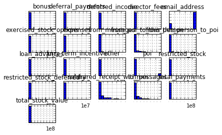

```python
# histograms of the attributes

mydataset.hist(sharex=False, sharey=False, xlabelsize=1, ylabelsize=1)

plt.show()
```

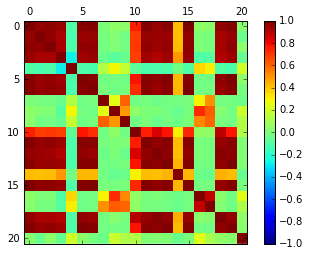

```python
# correlation matrix - this tells us that there are strong positive correlations with the certain attributes.
# Ideally we'd like to NOT see so much red in this graph. This also means we will need to consider various
# transformation in order to compensate for it.

fig = plt.figure()
ax = fig.add_subplot(111)
cax = ax.matshow(mydataset.corr(), vmin=-1, vmax=1, interpolation='none')
fig.colorbar(cax)
plt.show()
```

#### [TOC](#TableOfContents#UnimodalDataVisualizationSection)

### **ANALYSIS**

> **Correlation Matrix** - this tells us that there are strong positive correlations with the certain attributes. Ideally we'd like to NOT see so much red or blue in this graph. This also means we will probably need to consider some transformation in order to compensate for it.

> **Histograms of the attributes** - As expected the histograms are sometimes skewed, and could also benefit from some data transformations like standardization.

> **Outliers** - there is a potential of outliers which should be investigated.

#### [TOC](#TableOfContents#OutlierDetectionRemovalDescription)

# Task 2 - Outlier Detection & Removal

> By plotting some simple attributes, we get an intuitive sense of what the outlier is.

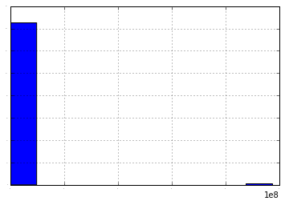

```python
mydataset['bonus'].hist(xlabelsize=1, ylabelsize=1)

plt.show()

# Note: Outlier Visible - TOTAL is the culpret
```

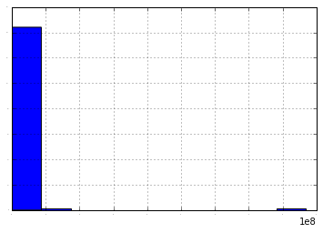

```python
mydataset['total_stock_value'].hist(xlabelsize=1, ylabelsize=1)

plt.show()

# Note: Outlier Visible - TOTAL is the culpret
```

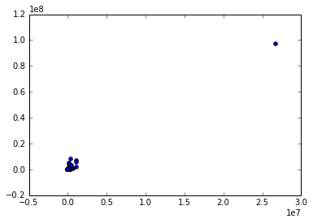

```python
plt.scatter(mydataset['salary'], mydataset['bonus'])

# Note: Outlier Visible - TOTAL is the culpret
```

#### [TOC](#TableOfContents#OutlierDetectionRemovalDescription)

### **ANALYSIS**

> These three plots show the existence of at least one outlier that is skewing the data significantly. In this case the above are clies to the real culpret, the record **"TOTAL"**, and it should be eliminated entirely.

#### [TOC](#TableOfContents#OutlierDetectionRemovalDescription)

## **Outlier Removal Prep** - Visually ID the outliers (both positive and negative)

```python
# High Outlier - this variable skews the distribution and needs to be removed.
# Detection Method - Plotting

mydataset.index.get_loc('TOTAL')
```

```
130
```

```python
# Low Outlier - this variable  might also skew the distribution and should be removed.
# Detection Method - visual

mydataset.index.get_loc('THE TRAVEL AGENCY IN THE PARK')
```

```
127
```

```python
# Spot check the index of the HIGH outlier

mydataset.index[130]
```

```
'TOTAL'
```

```python
# Spot check the index of the LOW outlier

mydataset.index[127]
```

```
'THE TRAVEL AGENCY IN THE PARK'
```

#### [TOC](#TableOfContents#OutlierDetectionRemovalDescription)

## **Outlier Removal** - Eliminate the outliers from the DF entirely

```python
# REMOVE OUTLIER: The Row "TOTAL" is an obvious outlier and is deleted entirely

mydataset.drop(mydataset.index[130], inplace=True)
```

```python
# REMOVE OUTLIER: The Row "THE TRAVEL AGENCY IN THE PARK" is also an obvious outlier and is deleted entirely

mydataset.drop(mydataset.index[127], inplace=True)
```

```python
# Spot Check the DF to make sure those data points no longer exist.

# for index in mydataset.index:
#    print index
```

#### [TOC](#TableOfContents#FeatureEngineeringSection)

# Task 3 - Features Engineering

> **NOTE** : Engineered Features not used in the final analysis due to inability to add enough information to adequately influence the classifier.

# Current High Value Attributes ['bonus', 'deferral_payments', 'deferred_income', 'director_fees', 'email_address', 'exercised_stock_options', 'expenses', 'from_messages', 'from_poi_to_this_person', 'from_this_person_to_poi', 'loan_advances', 'long_term_incentive', 'other', 'poi', 'restricted_stock', 'restricted_stock_deferred', 'salary', 'shared_receipt_with_poi', 'to_messages', 'total_payments', 'total_stock_value']

#### [TOC](#TableOfContents#FeatureEngineeringSection)

### Create new features using intuition alone.

> There are 3 engineered features below "**ratio_to**", "**ratio_from**" and "**big_shot**". The "ratio_to", "ratio_from" features both deal with email to and from POI's whereas the "big_shot" is a combination of "Highly Paid" and "High Net Worth".
- The idea is that a POI is most likely to have contributing attributes of a "Big Shot" which will likely contribute to successfully categorizing POI's.

```python
Highly_Paid = mydataset['salary'] + mydataset['bonus'] + mydataset['loan_advances'] + mydataset['other']
```

```python
High_Net_Worth = mydataset['exercised_stock_options'] + mydataset['restricted_stock']
```

```python
big_shot = Highly_Paid + High_Net_Worth
```

```python
mydataset['big_shot'] = big_shot
```

```python
mydataset['ratio_to'] = mydataset['from_this_person_to_poi'] / mydataset['to_messages']
```

```python
mydataset['ratio_from']= mydataset['from_poi_to_this_person'] / mydataset['from_messages']
```

#### [TOC](#TableOfContents#FeatureEngineeringSection)

### Post Feature Engineering Transformations

```python
reordered_column_list = [ 'bonus',
 'deferral_payments',
 'deferred_income',
 'director_fees',
 'email_address',
 'exercised_stock_options',
 'expenses',
 'from_messages',
 'from_poi_to_this_person',
 'from_this_person_to_poi',
 'loan_advances',
 'long_term_incentive',
 'other',
 'restricted_stock',
 'restricted_stock_deferred',
 'salary',
 'shared_receipt_with_poi',
 'to_messages',
 'total_payments',
 'total_stock_value',
 'ratio_to',
 'ratio_from',
 'big_shot',
 'poi'
]
```

```python
# DF TRANSFORM - Column ReOrdering

mydataset = mydataset[reordered_column_list]
```

```python
# Fill in the NaN's with Zero's

mydataset = mydataset.fillna(0)
```

```python
# Spot Check
mydataset.shape
```

```
(144, 24)
```

```python
# mydataset
```

#### [TOC](#TableOfContents#IntuitionFeaturesJustificationSection)

## Justification for Intuition based features

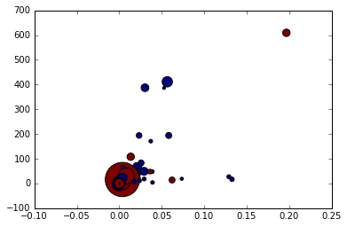

```python
# Plotting 4 variables in a scatter plot [ratio_to, from_this_person_to_poi, big_shot, poi]

# Adding in 3rd variable "poi" as Color
color = [str(item/255.) for item in  mydataset['poi']]

fig = plt.figure()
ax = fig.add_subplot(1,1,1)

# Adding in 4th variable "big_shot" as size of the bubble
ax.scatter(mydataset['ratio_to'],mydataset['from_this_person_to_poi'], s=mydataset['big_shot']/100000, c=color)


plt.show()
```

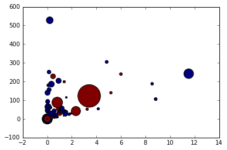

```python
# Plotting 4 variables in a scatter plot [ratio_from, from_poi_to_this_person, big_shot, poi]

color = [str(item/255.) for item in  mydataset['poi']]

# plt.scatter(ratio_to.fillna(0) , big_shot.fillna(0), s=70, c=color)

fig = plt.figure()
ax = fig.add_subplot(1,1,1)

# Adding in 4th variable "big_shot" as size of the bubble
ax.scatter(mydataset['ratio_from'],mydataset['from_poi_to_this_person'], s=mydataset['big_shot']/100000, c=color)

plt.show()
```

#### [TOC](#TableOfContents#IntuitionFeaturesJustificationSection)

### **ANALYSIS**

> My intuition tells me that two engineered features roughly corresponding to **"Highly Paid"** and **"High Net Worth"** could be direct or indirect contributors in some way to those "Persons Of Interest". In fact, I suspect that when combined into a new engineered feature **"Big Shot"** (a combination of the two) it could lend even more significance to the predictive capability of the classifier.

#### [TOC](#TableOfContents#ClassLabelsBallanceCheckSection)

### Check for Balance in the Class Labels

```python
# Spot Check - How many POI are in there?

len(mydataset.loc[mydataset['poi'] == 1])

# This is far too Few -> Imbalanced Class : Problem !!!
```

```
18
```

#### [TOC](#TableOfContents#ClassLabelsBallanceCheckSection)

### **DF TRANSFORM** : BEGIN - Oversampling processes - to cope with Imbalanced Classes problem.

```python
# Create a temp DF of the feature reduced df

temp_mydataset = mydataset.copy(deep=True)
```

```python
# Make a new DF of ONLY the POI's in the temp FR DF (ie. isolate only the POI's rows)

MyPoiDF = mydataset.loc[mydataset['poi'] == 1].copy(deep=True)
```

**Alter the Index of the Oversampled DF to be Unique**

> Further down the line, we have to convert the dataframe to a dictionary. That process will eliminate any duplicate row indexes (currently the persona name), so we have to ensure they are unique, this this process.

```python
# Do this ONLY ONCE per oversampling run to initialize.
start_range = 0
```

```python
# CHANGE the INDEX of the DF to a numeric range,
# this can be done multiple times in sequence to add to the oversampling.

# Calculate Proper Range Values for this individual DF
end_range = len(MyPoiDF)

# RESET the Temp POI DF (for unique indexes)
MyPoiDF.index=range(start_range, end_range + start_range)
```

```python
# Spot Check - Range of 0 to 17 as the Row index below?

MyPoiDF
```

[output not shown]

```python
# Begin the process of oversampling by appending the isolated POI's rows to an existing df

over_sampled_df = temp_mydataset.append(MyPoiDF)
```

```python
# Add a new set of identical isolated POI records to the over_sampled_df (repeatable to add more - if necessary)

# over_sampled_df = over_sampled_df.append(MyPoiDF)
```

```python
len(over_sampled_df)
```

```
162
```

```python
# Spot Check the total number of POI rows in the over_sampled_df

len(over_sampled_df.loc[over_sampled_df['poi'] == 1])
```

```
36
```

### **DF Transformation** (B): - END - Oversampling processes

> Oversampling - in cases where there is imbalanced data, and few overall records, add copies of instances from the under-represented class (oversampling) to get the algorithm to have more looks at positive labels.
- New DF: **over_sampled_df**

#### [TOC](#TableOfContents#ClassLabelsBallanceCheckSection)

## **Validation Dataset Extraction**

> It is a good idea to use a validation hold-out set. This is a sample of the data that we hold back from our analysis and modeling. We use it right at the end of our project to confirm the accuracy of our final model.

> It is a smoke test that we can use to see if we messed up and to give us confidence on our estimates of accuracy on unseen data. We will use **80% of the dataset for modeling** and **hold back 20% for validation.**

### **Validation Dataset (1a)** - Raw 21 Atrribute Feature Set => OVERSAMPLED Dataset

```python
# Split-out validation dataset (21 Attribute Feature Set)

array = over_sampled_df.values

# separate array into input and output components

X = array[:,0:20].astype(float) # NOTE: There are 23 columns, the category class is the 23rd, therefore exclude it.
Y = array[:,20]                 # NOTE: This is the isolated output class (or the 21st column)

validation_size = 0.20          # Validation Set Size 20%
seed = 7                        # Seed of 7 - for repeatability

# Split into train / validation sets
X_train, X_validation, Y_train, Y_validation = cross_validation.train_test_split(X, Y,
    test_size=validation_size, random_state=seed)
```

#### [TOC](#TableOfContents#AutomatedFeatureSelectionSection)

## **Automated Feature Selection**

### **ANALYSIS**

> I've chosen two methods (**RFE** and **KBest**) for automatic feature selection to create a comparison. I will execute both and see compare / contrast the results to determine which of the two I select. In the end I chose KBest as the algorithm of choice because it's results were a bit more intuitive and I suspect more accurate.
> - **NOTE:** - I've included the output (below) of both automatic feature selectors for posterity sake.

### **KBest:** ( 15 Influential Attributes Chosen)

**15 Selected Features (in bold)** and DataFrame Column Ordering:

- 1 '**bonus**',
- 2 '**deferral_payments**',
- 3 '**deferred_income**',
- 4 '**director_fees**',
- 5 'email_address',
- 6 '**exercised_stock_options**',
- 7 '**expenses**',
- 8 'from_messages',
- 9 'from_poi_to_this_person',
- 10 'from_this_person_to_poi',
- 11 '**loan_advances**',
- 12 '**long_term_incentive**',
- 13 '**other**',
- 14 '**restricted_stock**',
- 15 '**restricted_stock_deferred**',
- 16 '**salary**',
- 17 '**shared_receipt_with_poi**',
- 18 'to_messages',
- 19 '**total_payments**',
- 20 '**total_stock_value**',

**Engineered Features:**

- 21 ratio_to',
- 22 'ratio_from',
- 23 'big_shot',

**Class Label**

- 24 'poi'

#### [TOC](#TableOfContents#AutomatedFeatureSelectionSection)

### Recursive Feature Elimination (RFE)

```python
# The below uses RFE with the logistic regression algorithm to select the top X features.
# The choice of algorithm does not matter too much as long as it is skillful and consistent.

# Feature Extraction with RFE
from pandas import read_csv
from sklearn.feature_selection import RFE
from sklearn.linear_model import LogisticRegression


# feature extraction
model = LogisticRegression()
rfe = RFE(model, 13)
fit = rfe.fit(X, Y)


print("Num Features: %d") % fit.n_features_
print("Selected Features: %s") % fit.support_
print("Feature Ranking: %s") % fit.ranking_

# You can see that RFE chose the top X features. These are marked True in the support array and marked
# with a choice 1 in the ranking array. Again, you can manually map the feature indexes to the
# indexes of attribute names.
```

```
Num Features: 13
Selected Features: [ True False  True  True False False False  True  True  True  True  True
  True False  True False  True  True  True False]
Feature Ranking: [1 4 1 1 2 6 5 1 1 1 1 1 1 8 1 3 1 1 1 7]
```

#### [TOC](#TableOfContents#AutomatedFeatureSelectionSection)

### **SelectKBest**

```python
# Feature Extraction with Univariate Statistical Tests (Chi-squared for classification)

from sklearn.feature_selection import SelectKBest
from sklearn.feature_selection import chi2


# feature extraction  using the chi-squared (chi2) statistical test for non-negative features.
# http://scikit-learn.org/stable/modules/generated/sklearn.feature_selection.SelectKBest.html#sklearn.feature_selection.SelectKBest
# http://scikit-learn.org/stable/modules/feature_selection.html#univariate-feature-selection
#
featureSelector  = SelectKBest(score_func=chi2, k=15)
fit = featureSelector .fit(X, Y)

# summarize scores
numpy.set_printoptions(precision=3)
print "SCORES: \n", fit.scores_

print "\n"

assumed_to_be_the_feature_ids_of_the_top_k_features = list(featureSelector.get_support(indices=True))
print "Choosen Feature IDs: ", assumed_to_be_the_feature_ids_of_the_top_k_features

print "\n"
features = fit.transform(X)

# summarize selected features
print "FEATURES: \n", features[0:20,:]


# You can see the scores for each attribute and the X attributes chosen
# (those with the HIGHEST scores chi^2 scores or highest selection score)
#
# I got the names for the chosen attributes by manually mapping the index of the
# X HIGHEST chi scores (but highest index scores) to the index of the attribute names.
```

```
SCORES:
[  6.196e+07   1.066e+06   2.907e+07   4.106e+05   2.412e+00   3.351e+08
   5.761e+05   1.769e+03   1.186e+03   9.830e+02   5.577e+08   2.045e+07
   2.690e+07   5.766e+07   5.837e+06   5.568e+06   2.199e+04   1.149e+04
   4.057e+08   3.969e+08]


Choosen Feature IDs:  [0, 1, 2, 3, 5, 6, 10, 11, 12, 13, 14, 15, 16, 18, 19]


FEATURES:
[[  4.175e+06   2.870e+06   3.081e+06   0.000e+00   1.730e+06   1.387e+04
    0.000e+00   3.048e+05   1.520e+02   1.260e+05   1.260e+05   2.020e+05
    1.407e+03   4.484e+06   1.730e+06]
 [  0.000e+00   1.790e+05   0.000e+00   0.000e+00   2.578e+05   3.486e+03
    0.000e+00   0.000e+00   0.000e+00   0.000e+00   0.000e+00   0.000e+00
    0.000e+00   1.825e+05   2.578e+05]
 [  0.000e+00   0.000e+00   5.104e+03   0.000e+00   4.046e+06   5.630e+04
    0.000e+00   0.000e+00   8.645e+05   1.758e+06   5.602e+05   4.770e+02
    4.650e+02   9.162e+05   5.243e+06]
 [  1.200e+06   1.296e+06   1.386e+06   0.000e+00   6.681e+06   1.120e+04
    0.000e+00   1.586e+06   2.660e+06   3.943e+06   0.000e+00   2.671e+05
    0.000e+00   5.634e+06   1.062e+07]
 [  4.000e+05   2.605e+05   2.016e+05   0.000e+00   0.000e+00   1.291e+05
    0.000e+00   0.000e+00   6.900e+01   1.458e+05   8.278e+04   2.397e+05
    0.000e+00   8.277e+05   6.301e+04]
 [  0.000e+00   6.847e+05   0.000e+00   0.000e+00   1.600e+06   0.000e+00
    0.000e+00   9.375e+04   8.740e+02   0.000e+00   0.000e+00   8.082e+04
    0.000e+00   8.601e+05   1.600e+06]
 [  7.000e+05   0.000e+00   0.000e+00   0.000e+00   0.000e+00   3.717e+04
    0.000e+00   0.000e+00   5.660e+02   1.260e+05   0.000e+00   2.313e+05
    2.639e+03   9.691e+05   1.260e+05]
 [  5.250e+06   2.144e+06   2.334e+06   0.000e+00   9.531e+05   1.736e+04
    0.000e+00   0.000e+00   2.107e+05   1.576e+05   0.000e+00   2.140e+05
    5.521e+03   5.502e+06   1.111e+06]
 [  0.000e+00   1.025e+05   0.000e+00   3.285e+03   3.285e+03   0.000e+00
    0.000e+00   0.000e+00   0.000e+00   0.000e+00   4.409e+04   0.000e+00
    0.000e+00   1.025e+05   4.409e+04]
 [  0.000e+00   0.000e+00   0.000e+00   0.000e+00   1.624e+06   1.189e+04
    0.000e+00   0.000e+00   0.000e+00   8.692e+05   0.000e+00   2.166e+05
```

[output cut: 16 more lines]

```
 [  1.350e+06   0.000e+00   8.330e+02   0.000e+00   0.000e+00   6.591e+04
    0.000e+00   9.743e+05   1.621e+03   2.521e+05   0.000e+00   2.786e+05
    1.593e+03   2.670e+06   2.521e+05]
 [  0.000e+00   0.000e+00   0.000e+00   0.000e+00   0.000e+00   4.929e+04
    0.000e+00   0.000e+00   0.000e+00   0.000e+00   0.000e+00   0.000e+00
    7.610e+02   4.929e+04   0.000e+00]
 [  5.000e+05   0.000e+00   0.000e+00   0.000e+00   8.255e+05   6.000e+02
    0.000e+00   3.048e+05   1.215e+03   1.890e+05   0.000e+00   2.480e+05
    2.300e+01   1.055e+06   1.015e+06]
 [  7.500e+05   0.000e+00   7.500e+04   0.000e+00   0.000e+00   9.410e+03
    0.000e+00   1.750e+05   1.507e+05   4.176e+05   0.000e+00   2.615e+05
    0.000e+00   1.272e+06   4.176e+05]
 [  9.000e+05   6.496e+05   6.949e+05   0.000e+00   2.543e+06   0.000e+00
    0.000e+00   7.699e+05   4.006e+05   9.017e+05   0.000e+00   3.305e+05
    2.333e+03   2.356e+06   3.444e+06]]
```

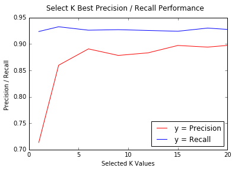

```python
import matplotlib.pyplot as plt
import numpy as np

# Precision values for K=1,3,6,9,12,15,18,20
x = np.array([0.71340, 0.85965, 0.89060, 0.87826, 0.88311, 0.89709, 0.89402, 0.89722])

# Recall values for K=1,3,6,9,12,15,18,20
y = np.array([0.92350, 0.93250, 0.92600, 0.92700, 0.92550, 0.92400, 0.93000, 0.92750])

# Values of K (Features selected via KBest)
z = np.array([1, 3, 6, 9, 12, 15, 18, 20])

plt.gca().set_color_cycle(['red', 'blue'])

plt.plot(z, x)
plt.plot(z, y)

plt.suptitle('Select K Best Precision / Recall Performance', fontsize=12)
plt.legend(['y = Precision', 'y = Recall'], loc='lower right')
plt.xlabel('Selected K Values', fontsize=10)
plt.ylabel('Precision / Recall ', fontsize=10)

plt.show()
```

#### [TOC](#TableOfContents#FeatureReductionSection)

### DF TRANSFORM : Feature Reduction - as a result of the SelectKBest feature picking process

**15 Selected Features (in bold)** and DataFrame Column Ordering:

- 1 '**bonus**',
- 2 '**deferral_payments**',
- 3 '**deferred_income**',
- 4 '**director_fees**',
- 5 'email_address',
- 6 '**exercised_stock_options**',
- 7 '**expenses**',
- 8 'from_messages',
- 9 'from_poi_to_this_person',
- 10 'from_this_person_to_poi',
- 11 '**loan_advances**',
- 12 '**long_term_incentive**',
- 13 '**other**',
- 14 '**restricted_stock**',
- 15 '**restricted_stock_deferred**',
- 16 '**salary**',
- 17 '**shared_receipt_with_poi**',
- 18 'to_messages',
- 19 '**total_payments**',
- 20 '**total_stock_value**',

**Engineered Features:**

- 21 ratio_to',
- 22 'ratio_from',
- 23 'big_shot',

**Class Label**

- 24 'poi'

```python
# Create a dataset from a feature reduced columns (per KBest feature picking process + Tweeks) : 16 Total

mydataset_os_fr = over_sampled_df[['bonus','deferral_payments','deferred_income','director_fees',
                                   'exercised_stock_options','expenses','loan_advances','long_term_incentive',
                                   'other','restricted_stock','restricted_stock_deferred','salary',
                                   'shared_receipt_with_poi','total_payments','total_stock_value','poi']]
```

```python
# Spot Check - DF Shape

mydataset_os_fr.shape
```

```
(162, 16)
```

#### [TOC](#TableOfContents#FeatureReductionSection)

### **Validation Dataset** - Oversampled DF - Feature Reduced - 15 Atrribute Feature Set

```python
# Split-out validation dataset

array = mydataset_os_fr.values

# separate array into input and output components

X = array[:,0:15].astype(float) # NOTE: There are 16 columns, the category class is the 15th, therefore exclude it.
Y = array[:,15]                 # NOTE: This is the isolated output class (or the 15th column)

validation_size = 0.20          # Validation Set Size 20%
seed = 7                        # Seed of 7

# Split into train / validation sets
X_train, X_validation, Y_train, Y_validation = cross_validation.train_test_split(X, Y,
    test_size=validation_size, random_state=seed)
```

#### [TOC](#TableOfContents#EvaluateClassifiersDescription)

# Task 4 - Evaluate Classifiers

## **Evaluate Algorithms: Baseline** - no standardizing or normalizing of data (yet)

> **We don't know what algorithms will do well on this dataset.** Gut feel suggests **distance based algorithms** like **K-Nearest Neighbors** and **Support Vector Machines** may do well, but also **rule based algorithms** such as **Decision Trees**.

> Designing the test harness, we will use **10-fold cross validation**. The dataset is not too small and this is a good standard test harness configuration. We will **evaluate algorithms** using the **accuracy metric**. This is a **gross metric** that will give a quick idea of **how correct a given model is**.
- More useful on **binary classification** problems like this one.

```python
# Test options and evaluation metric - used OFTEN later on - these are effectively CONSTANTS

num_folds = 10
num_instances = len(X_train)
seed = 7
scoring = 'accuracy' # This is a gross metric that will give a quick idea of how correct a given model is.
```

> Let's create a **baseline of performance** on this problem and **spot-check** a number of different algorithms. We will **select a suite of different algorithms** capable of working on **this (Binary type) classification problem**.

The six algorithms selected include:

> **Linear Algorithms:**
- Logistic Regression (LR)
- Linear Discriminant Analysis (LDA)

> **Nonlinear Algorithms:**
- Classiffcation and Regression Trees (CART)
- Support Vector Machines (SVM)
- Gaussian Naive Bayes (NB)
- K-Nearest Neighbors (KNN)

```python
# Construct Algorithms List

models = []
models.append(('LR', LogisticRegression()))
models.append(('LDA', LinearDiscriminantAnalysis()))
models.append(('KNN', KNeighborsClassifier()))
models.append(('CART', DecisionTreeClassifier()))
models.append(('NB', GaussianNB()))
models.append(('SVM', SVC()))
```

#### [TOC](#TableOfContents#EvaluateClassifiersDescription)

### Compare Baseline Algorithms

> The algorithms all use **default tuning parameters**. Let's compare the algorithms. We will display the **mean** and **standard deviation** of accuracy for each algorithm as we calculate it and **collect the results for use later.**

```python
# Execute them using Default Tuning Parameters ...

results = []
names = []
for name, model in models:
    kfold = cross_validation.KFold(n=num_instances, n_folds=num_folds, random_state=seed)
    cv_results = cross_validation.cross_val_score(model, X_train, Y_train, cv=kfold, scoring=scoring)
    results.append(cv_results)
    names.append(name)
    msg = "%s: MEAN: %f STD: (%f)" % (name, cv_results.mean(), cv_results.std())
    print(msg)


# Running the example provides the output below.

# NOTICE the "Colinear" warming dissappeared after various Data Transformation
```

```
LR: MEAN: 0.728205 STD: (0.111295)
LDA: MEAN: 0.767308 STD: (0.133360)
KNN: MEAN: 0.821154 STD: (0.070946)
CART: MEAN: 0.821795 STD: (0.097377)
NB: MEAN: 0.759615 STD: (0.130783)
SVM: MEAN: 0.914744 STD: (0.087333)
```

> **These are just Mean Accuracy values.** It is always wise to look at the **distribution of accuracy values calculated across cross validation folds**.
- We can do that graphically using box and whisker plots.

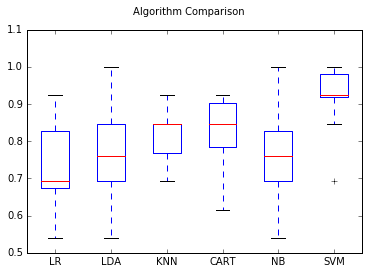

```python
# Compare Algorithms

fig = plt.figure()
fig.suptitle('Algorithm Comparison')
ax = fig.add_subplot(111)
plt.boxplot(results)
ax.set_xticklabels(names)
plt.show()
```

#### [TOC](#TableOfContents#EvaluateClassifiersDescription)

### ANALYSIS:

#### [TOC](#TableOfContents#StandardizedDataSection)

## **Evaluate Algorithms: Standardize Data**

> We suspect that the **differing distributions** of the raw data may be **negatively impacting** the performance of some of the algorithms, so we'll scale the input to a standard. Any algorithm preferring input features in a normal distribution are targets for scaling.
- **Note:** - I'll evaluate the same algorithms with a **standardized input copy**. Since this is section is intended to be an apples to apples comparison, I will use feature scaling even if some algorithms might not require it (aka : DecisionTreeClassifier), although most will benefit from scaling, such as:

> > LogisticRegression

> > LinearDiscriminantAnalysis

> > KNeighborsClassifier

> > GaussianNB

> > SVC
- there are those which do not specifically require it:

  > > DecisionTreeClassifier

> This is where the data is **transformed** such that each attribute has a **mean value of zero** and a **standard deviation of one**.

> We also need to **avoid data leakage** when we transform the data. A good way to avoid leakage is to **use pipelines** that standardize the data and build the model for each fold **in** the cross validation test harness.
- That way we can get a **fair estimation** of how each model with standardized data might perform on unseen data.

```python
# Eestablish the pipelines for testing against standardized data

pipelines = []
pipelines.append(('ScaledLR', Pipeline([('Scaler', StandardScaler()),('LR',LogisticRegression())])))
pipelines.append(('ScaledLDA', Pipeline([('Scaler', StandardScaler()),('LDA',LinearDiscriminantAnalysis())])))
pipelines.append(('ScaledKNN', Pipeline([('Scaler', StandardScaler()),('KNN',KNeighborsClassifier())])))
pipelines.append(('ScaledCART', Pipeline([('Scaler', StandardScaler()),('CART',DecisionTreeClassifier())])))
pipelines.append(('ScaledNB', Pipeline([('Scaler', StandardScaler()),('NB',GaussianNB())])))
pipelines.append(('ScaledSVM', Pipeline([('Scaler', StandardScaler()),('SVM', SVC())])))

results = []
names = []


# Process each dataset in their respective pipelines
for name, model in pipelines:
    kfold = cross_validation.KFold(n=num_instances, n_folds=num_folds, random_state=seed)
    cv_results = cross_validation.cross_val_score(model, X_train, Y_train, cv=kfold, scoring=scoring)
    results.append(cv_results)
    names.append(name)
    msg = "%s: %f (%f)" % (name, cv_results.mean(), cv_results.std())
    print(msg)


# Running the example provides the results listed below.
```

```
ScaledLR: 0.790385 (0.146571)
ScaledLDA: 0.767308 (0.133360)
ScaledKNN: 0.790385 (0.092007)
ScaledCART: 0.829487 (0.095948)
ScaledNB: 0.433974 (0.128846)
ScaledSVM: 0.821795 (0.103275)
```

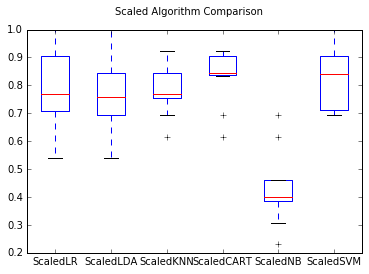

```python
# Compare Algorithms

fig = plt.figure()
fig.suptitle('Scaled Algorithm Comparison')
ax = fig.add_subplot(111)
plt.boxplot(results)
ax.set_xticklabels(names)
plt.show()
```

#### [TOC](#TableOfContents#StandardizedDataSection)

### ANALYSIS:

> On Scaled Data, CART, LR , LDA, and SVM all are performing well in addition to KNN slipping a bit.
- The Box Plots reflect these findings.

#### [TOC](#TableOfContents#TuneClassifiersDescription)

# Task 5 - Tune Classifier Algorithms

### TASK: Achieve better than (.3) Precision and (.3) Recall using the test script.

- It is very likely that **configuration beyond the default** may yield even **more accurate models.**
- We'll execute a **grid search** for the optimal parameter set and display the best candidates.
- We **only** search for optimal tuning parameters for those algorithms which have proven worthy to investigate further.

#### [TOC](#TableOfContents#TuneClassifiersDescription)

### **(1) Tuning LDA**

```python
# Scale the Input Data:

scaler = StandardScaler().fit(X_train)
rescaledX = scaler.transform(X_train)

# Set the parameter values of concern

solver_value = ['svd', 'lsqr']

param_grid = dict(solver=solver_value)     # Grid
model_LDA = LinearDiscriminantAnalysis()   # Model

# KFOLD Validation Execution & Grid Search

kfold = cross_validation.KFold(n=num_instances, n_folds=num_folds, random_state=seed)
grid = GridSearchCV(estimator=model_LDA, param_grid=param_grid, scoring=scoring, cv=kfold)
grid_result = grid.fit(rescaledX, Y_train)

print("Best: MEAN: %f using %s" % (grid_result.best_score_, grid_result.best_params_)), "\n"
for params, mean_score, scores in grid_result.grid_scores_:
    print(" MEAN: %f STD: (%f) with: %r" % (scores.mean(), scores.std(), params))



# SIMPLE ACCURACY SCORE

model_LDA.fit(rescaledX, Y_train)
# estimate accuracy on validation dataset
rescaledValidationX = scaler.transform(X_validation)
predictions = model_LDA.predict(rescaledValidationX)
print "\nSimple Accuracy Score: ", accuracy_score(Y_validation, predictions)


# We can print out configuration that resulted in the highest accuracy as
# well as the accuracy of all values tried. Running the example we see the results below.
```

```
Best: MEAN: 0.767442 using {'solver': 'svd'}

 MEAN: 0.767308 STD: (0.133360) with: {'solver': 'svd'}
 MEAN: 0.767308 STD: (0.133360) with: {'solver': 'lsqr'}

Simple Accuracy Score:  0.757575757576
```

#### [TOC](#TableOfContents#TuneClassifiersDescription)

### **(2) Tuning KNN**

```python
# Scale the Input Data:

scaler = StandardScaler().fit(X_train)
rescaledX = scaler.transform(X_train)

# Set the parameter values of concern

neighbors = [1,3,5,7,9,11,13,15,17,19,21]    # parameter List to Try
param_grid = dict(n_neighbors=neighbors)     # Grid
model_KNN = KNeighborsClassifier()           # Model


# KFOLD Validation Execution & Grid Search

kfold = cross_validation.KFold(n=num_instances, n_folds=num_folds, random_state=seed)
grid = GridSearchCV(estimator=model_KNN, param_grid=param_grid, scoring=scoring, cv=kfold)
grid_result = grid.fit(rescaledX, Y_train)

print("Best: MEAN: %f using %s" % (grid_result.best_score_, grid_result.best_params_)), "\n"
for params, mean_score, scores in grid_result.grid_scores_:
    print(" MEAN: %f STD: (%f) with: %r" % (scores.mean(), scores.std(), params))



# SIMPLE ACCURACY SCORE

model_KNN.fit(rescaledX, Y_train)
# estimate accuracy on validation dataset
rescaledValidationX = scaler.transform(X_validation)
predictions = model_KNN.predict(rescaledValidationX)
print "\nSimple Accuracy Score: ", accuracy_score(Y_validation, predictions)


# We can print out configuration that resulted in the highest accuracy as
# well as the accuracy of all values tried. Running the example we see the results below.
```

```
Best: MEAN: 0.875969 using {'n_neighbors': 1}

 MEAN: 0.875641 STD: (0.062295) with: {'n_neighbors': 1}
 MEAN: 0.744231 STD: (0.124050) with: {'n_neighbors': 3}
 MEAN: 0.790385 STD: (0.092007) with: {'n_neighbors': 5}
 MEAN: 0.759615 STD: (0.087389) with: {'n_neighbors': 7}
 MEAN: 0.759615 STD: (0.072595) with: {'n_neighbors': 9}
 MEAN: 0.735897 STD: (0.080310) with: {'n_neighbors': 11}
 MEAN: 0.766667 STD: (0.079817) with: {'n_neighbors': 13}
 MEAN: 0.743590 STD: (0.105097) with: {'n_neighbors': 15}
 MEAN: 0.743590 STD: (0.086574) with: {'n_neighbors': 17}
 MEAN: 0.743590 STD: (0.071611) with: {'n_neighbors': 19}
 MEAN: 0.735897 STD: (0.087368) with: {'n_neighbors': 21}

Simple Accuracy Score:  0.69696969697
```

#### [TOC](#TableOfContents#TuneClassifiersDescription)

### **(3) Tuning SVM**

```python
# Scale the input data

scaler = StandardScaler().fit(X_train)
rescaledX = scaler.transform(X_train)

# Set the parameter values of concern

c_values = [0.1, 0.3, 0.5, 0.7, 0.9, 1.0, 1.3, 1.5, 1.7, 2.0]  # Parameter Values
kernel_values = ['linear', 'poly', 'rbf', 'sigmoid']           # Kernel Types
param_grid = dict(C=c_values, kernel=kernel_values)            # Grid
model_SVC = SVC()                                              # Model


# KFOLD Validation Execution & Grid Search

kfold = cross_validation.KFold(n=num_instances, n_folds=num_folds, random_state=seed)
grid = GridSearchCV(estimator=model_SVC, param_grid=param_grid, scoring=scoring, cv=kfold)
grid_result = grid.fit(rescaledX, Y_train)

print("Best: %f using %s" % (grid_result.best_score_, grid_result.best_params_)), "\n"
for params, mean_score, scores in grid_result.grid_scores_:
    print(" MEAN: %f STD: (%f) with: %r" % (scores.mean(), scores.std(), params))



# SIMPLE ACCURACY SCORE

model_SVC.fit(rescaledX, Y_train)
# estimate accuracy on validation dataset
rescaledValidationX = scaler.transform(X_validation)
predictions = model_SVC.predict(rescaledValidationX)
print "\nSimple Accuracy Score: ", accuracy_score(Y_validation, predictions)


# Running the example prints out the best configuration, the accuracy as
# well as the accuracies for all configuration combinations.
```

```
Best: 0.821705 using {'kernel': 'rbf', 'C': 0.7}

 MEAN: 0.798077 STD: (0.125590) with: {'kernel': 'linear', 'C': 0.1}
 MEAN: 0.806410 STD: (0.109756) with: {'kernel': 'poly', 'C': 0.1}
 MEAN: 0.775641 STD: (0.086432) with: {'kernel': 'rbf', 'C': 0.1}
 MEAN: 0.775641 STD: (0.086432) with: {'kernel': 'sigmoid', 'C': 0.1}
 MEAN: 0.798077 STD: (0.125590) with: {'kernel': 'linear', 'C': 0.3}
 MEAN: 0.798718 STD: (0.097983) with: {'kernel': 'poly', 'C': 0.3}
 MEAN: 0.775641 STD: (0.086432) with: {'kernel': 'rbf', 'C': 0.3}
 MEAN: 0.775641 STD: (0.086432) with: {'kernel': 'sigmoid', 'C': 0.3}
 MEAN: 0.790385 STD: (0.114887) with: {'kernel': 'linear', 'C': 0.5}
 MEAN: 0.814103 STD: (0.091960) with: {'kernel': 'poly', 'C': 0.5}
 MEAN: 0.798718 STD: (0.109396) with: {'kernel': 'rbf', 'C': 0.5}
 MEAN: 0.775641 STD: (0.086432) with: {'kernel': 'sigmoid', 'C': 0.5}
 MEAN: 0.790385 STD: (0.114887) with: {'kernel': 'linear', 'C': 0.7}
 MEAN: 0.806410 STD: (0.104225) with: {'kernel': 'poly', 'C': 0.7}
 MEAN: 0.821795 STD: (0.103275) with: {'kernel': 'rbf', 'C': 0.7}
 MEAN: 0.775641 STD: (0.086432) with: {'kernel': 'sigmoid', 'C': 0.7}
 MEAN: 0.775000 STD: (0.131009) with: {'kernel': 'linear', 'C': 0.9}
 MEAN: 0.806410 STD: (0.104225) with: {'kernel': 'poly', 'C': 0.9}
 MEAN: 0.821795 STD: (0.103275) with: {'kernel': 'rbf', 'C': 0.9}
 MEAN: 0.775641 STD: (0.086432) with: {'kernel': 'sigmoid', 'C': 0.9}
 MEAN: 0.767308 STD: (0.141956) with: {'kernel': 'linear', 'C': 1.0}
 MEAN: 0.806410 STD: (0.104225) with: {'kernel': 'poly', 'C': 1.0}
 MEAN: 0.821795 STD: (0.103275) with: {'kernel': 'rbf', 'C': 1.0}
 MEAN: 0.775641 STD: (0.086432) with: {'kernel': 'sigmoid', 'C': 1.0}
 MEAN: 0.767308 STD: (0.141956) with: {'kernel': 'linear', 'C': 1.3}
 MEAN: 0.806410 STD: (0.104225) with: {'kernel': 'poly', 'C': 1.3}
 MEAN: 0.814103 STD: (0.091960) with: {'kernel': 'rbf', 'C': 1.3}
 MEAN: 0.775641 STD: (0.086432) with: {'kernel': 'sigmoid', 'C': 1.3}
 MEAN: 0.767308 STD: (0.141956) with: {'kernel': 'linear', 'C': 1.5}
 MEAN: 0.806410 STD: (0.104225) with: {'kernel': 'poly', 'C': 1.5}
 MEAN: 0.806410 STD: (0.085514) with: {'kernel': 'rbf', 'C': 1.5}
 MEAN: 0.775641 STD: (0.086432) with: {'kernel': 'sigmoid', 'C': 1.5}
 MEAN: 0.759615 STD: (0.130783) with: {'kernel': 'linear', 'C': 1.7}
 MEAN: 0.806410 STD: (0.104225) with: {'kernel': 'poly', 'C': 1.7}
 MEAN: 0.806410 STD: (0.085514) with: {'kernel': 'rbf', 'C': 1.7}
 MEAN: 0.775641 STD: (0.086432) with: {'kernel': 'sigmoid', 'C': 1.7}
 MEAN: 0.767308 STD: (0.133360) with: {'kernel': 'linear', 'C': 2.0}
 MEAN: 0.806410 STD: (0.104225) with: {'kernel': 'poly', 'C': 2.0}
 MEAN: 0.790385 STD: (0.078092) with: {'kernel': 'rbf', 'C': 2.0}
 MEAN: 0.775641 STD: (0.086432) with: {'kernel': 'sigmoid', 'C': 2.0}

Simple Accuracy Score:  0.909090909091
```

#### [TOC](#TableOfContents#TuneClassifiersDescription)

### **(4) Tuning the CART** Algorithm

```python
# Scale the input data

scaler = StandardScaler().fit(X_train)
rescaledX = scaler.transform(X_train)


# Set the parameter values of concern

criterion_values = ['gini', 'entropy']
min_samples_split_values = [1, 2, 3, 4]
splitter_values = ['best', 'random']
max_features_values = [7, 9, 12, 'auto', 'sqrt', 'log2']
class_weight_values = [{1: 1} , {0: .5}]
                                                              # Grid
param_grid = dict(criterion=criterion_values,min_samples_split=min_samples_split_values,splitter=splitter_values,
                 max_features=max_features_values,class_weight=class_weight_values)
model_DTC = DecisionTreeClassifier()                          # Model


# KFOLD Validation Execution & Grid Search

kfold = cross_validation.KFold(n=num_instances, n_folds=num_folds, random_state=seed)
grid = GridSearchCV(estimator=model_DTC, param_grid=param_grid, scoring=scoring, cv=kfold)
grid_result = grid.fit(rescaledX, Y_train)


# OutPut Results:

print("Best: %f using %s" % (grid_result.best_score_, grid_result.best_params_)), "\n"
for params, mean_score, scores in grid_result.grid_scores_:
    print("%f (%f) with: %r" % (scores.mean(), scores.std(), params))


# SIMPLE ACCURACY SCORE
model_DTC.fit(rescaledX, Y_train)
# estimate accuracy on validation dataset
rescaledValidationX = scaler.transform(X_validation)
predictions = model_DTC.predict(rescaledValidationX)
print "\nSimple Accuracy Score: ", accuracy_score(Y_validation, predictions)



# Running the example prints out the best configuration, the accuracy as
# well as the accuracies for all configuration combinations.
```

```
Best: 0.899225 using {'max_features': 'auto', 'min_samples_split': 4, 'splitter': 'best', 'criterion': 'gini', 'class_weight': {0: 0.5}}

0.860256 (0.107944) with: {'max_features': 7, 'min_samples_split': 1, 'splitter': 'best', 'criterion': 'gini', 'class_weight': {1: 1}}
0.828846 (0.108939) with: {'max_features': 7, 'min_samples_split': 1, 'splitter': 'random', 'criterion': 'gini', 'class_weight': {1: 1}}
0.820513 (0.140442) with: {'max_features': 7, 'min_samples_split': 2, 'splitter': 'best', 'criterion': 'gini', 'class_weight': {1: 1}}
0.837179 (0.063859) with: {'max_features': 7, 'min_samples_split': 2, 'splitter': 'random', 'criterion': 'gini', 'class_weight': {1: 1}}
0.806410 (0.109756) with: {'max_features': 7, 'min_samples_split': 3, 'splitter': 'best', 'criterion': 'gini', 'class_weight': {1: 1}}
0.860256 (0.083175) with: {'max_features': 7, 'min_samples_split': 3, 'splitter': 'random', 'criterion': 'gini', 'class_weight': {1: 1}}
0.791026 (0.128468) with: {'max_features': 7, 'min_samples_split': 4, 'splitter': 'best', 'criterion': 'gini', 'class_weight': {1: 1}}
0.798077 (0.079407) with: {'max_features': 7, 'min_samples_split': 4, 'splitter': 'random', 'criterion': 'gini', 'class_weight': {1: 1}}
0.837179 (0.105728) with: {'max_features': 9, 'min_samples_split': 1, 'splitter': 'best', 'criterion': 'gini', 'class_weight': {1: 1}}
0.852564 (0.087565) with: {'max_features': 9, 'min_samples_split': 1, 'splitter': 'random', 'criterion': 'gini', 'class_weight': {1: 1}}
0.851923 (0.122851) with: {'max_features': 9, 'min_samples_split': 2, 'splitter': 'best', 'criterion': 'gini', 'class_weight': {1: 1}}
0.812821 (0.089597) with: {'max_features': 9, 'min_samples_split': 2, 'splitter': 'random', 'criterion': 'gini', 'class_weight': {1: 1}}
0.804487 (0.134867) with: {'max_features': 9, 'min_samples_split': 3, 'splitter': 'best', 'criterion': 'gini', 'class_weight': {1: 1}}
0.782692 (0.118562) with: {'max_features': 9, 'min_samples_split': 3, 'splitter': 'random', 'criterion': 'gini', 'class_weight': {1: 1}}
0.782692 (0.132692) with: {'max_features': 9, 'min_samples_split': 4, 'splitter': 'best', 'criterion': 'gini', 'class_weight': {1: 1}}
0.789103 (0.133618) with: {'max_features': 9, 'min_samples_split': 4, 'splitter': 'random', 'criterion': 'gini', 'class_weight': {1: 1}}
0.813462 (0.121032) with: {'max_features': 12, 'min_samples_split': 1, 'splitter': 'best', 'criterion': 'gini', 'class_weight': {1: 1}}
0.805769 (0.130557) with: {'max_features': 12, 'min_samples_split': 1, 'splitter': 'random', 'criterion': 'gini', 'class_weight': {1: 1}}
0.860256 (0.083175) with: {'max_features': 12, 'min_samples_split': 2, 'splitter': 'best', 'criterion': 'gini', 'class_weight': {1: 1}}
0.851923 (0.122851) with: {'max_features': 12, 'min_samples_split': 2, 'splitter': 'random', 'criterion': 'gini', 'class_weight': {1: 1}}
0.821154 (0.104644) with: {'max_features': 12, 'min_samples_split': 3, 'splitter': 'best', 'criterion': 'gini', 'class_weight': {1: 1}}
0.845513 (0.090494) with: {'max_features': 12, 'min_samples_split': 3, 'splitter': 'random', 'criterion': 'gini', 'class_weight': {1: 1}}
0.821795 (0.097377) with: {'max_features': 12, 'min_samples_split': 4, 'splitter': 'best', 'criterion': 'gini', 'class_weight': {1: 1}}
0.789103 (0.119597) with: {'max_features': 12, 'min_samples_split': 4, 'splitter': 'random', 'criterion': 'gini', 'class_weight': {1: 1}}
0.868590 (0.153826) with: {'max_features': 'auto', 'min_samples_split': 1, 'splitter': 'best', 'criterion': 'gini', 'class_weight': {1: 1}}
0.798077 (0.099276) with: {'max_features': 'auto', 'min_samples_split': 1, 'splitter': 'random', 'criterion': 'gini', 'class_weight': {1: 1}}
0.798077 (0.120787) with: {'max_features': 'auto', 'min_samples_split': 2, 'splitter': 'best', 'criterion': 'gini', 'class_weight': {1: 1}}
0.821154 (0.129875) with: {'max_features': 'auto', 'min_samples_split': 2, 'splitter': 'random', 'criterion': 'gini', 'class_weight': {1: 1}}
0.852564 (0.105915) with: {'max_features': 'auto', 'min_samples_split': 3, 'splitter': 'best', 'criterion': 'gini', 'class_weight': {1: 1}}
0.812821 (0.101953) with: {'max_features': 'auto', 'min_samples_split': 3, 'splitter': 'random', 'criterion': 'gini', 'class_weight': {1: 1}}
0.782692 (0.128155) with: {'max_features': 'auto', 'min_samples_split': 4, 'splitter': 'best', 'criterion': 'gini', 'class_weight': {1: 1}}
0.750641 (0.131573) with: {'max_features': 'auto', 'min_samples_split': 4, 'splitter': 'random', 'criterion': 'gini', 'class_weight': {1: 1}}
0.837821 (0.079655) with: {'max_features': 'sqrt', 'min_samples_split': 1, 'splitter': 'best', 'criterion': 'gini', 'class_weight': {1: 1}}
0.844872 (0.103275) with: {'max_features': 'sqrt', 'min_samples_split': 1, 'splitter': 'random', 'criterion': 'gini', 'class_weight': {1: 1}}
0.853205 (0.099574) with: {'max_features': 'sqrt', 'min_samples_split': 2, 'splitter': 'best', 'criterion': 'gini', 'class_weight': {1: 1}}
0.775000 (0.126412) with: {'max_features': 'sqrt', 'min_samples_split': 2, 'splitter': 'random', 'criterion': 'gini', 'class_weight': {1: 1}}
0.859615 (0.103935) with: {'max_features': 'sqrt', 'min_samples_split': 3, 'splitter': 'best', 'criterion': 'gini', 'class_weight': {1: 1}}
0.821795 (0.108854) with: {'max_features': 'sqrt', 'min_samples_split': 3, 'splitter': 'random', 'criterion': 'gini', 'class_weight': {1: 1}}
```

[output cut: 141 more lines]

```
0.836538 (0.074604) with: {'max_features': 'sqrt', 'min_samples_split': 2, 'splitter': 'random', 'criterion': 'entropy', 'class_weight': {0: 0.5}}
0.821154 (0.169416) with: {'max_features': 'sqrt', 'min_samples_split': 3, 'splitter': 'best', 'criterion': 'entropy', 'class_weight': {0: 0.5}}
0.876282 (0.070107) with: {'max_features': 'sqrt', 'min_samples_split': 3, 'splitter': 'random', 'criterion': 'entropy', 'class_weight': {0: 0.5}}
0.860897 (0.136466) with: {'max_features': 'sqrt', 'min_samples_split': 4, 'splitter': 'best', 'criterion': 'entropy', 'class_weight': {0: 0.5}}
0.752564 (0.131502) with: {'max_features': 'sqrt', 'min_samples_split': 4, 'splitter': 'random', 'criterion': 'entropy', 'class_weight': {0: 0.5}}
0.812821 (0.118088) with: {'max_features': 'log2', 'min_samples_split': 1, 'splitter': 'best', 'criterion': 'entropy', 'class_weight': {0: 0.5}}
0.814103 (0.138230) with: {'max_features': 'log2', 'min_samples_split': 1, 'splitter': 'random', 'criterion': 'entropy', 'class_weight': {0: 0.5}}
0.851282 (0.109868) with: {'max_features': 'log2', 'min_samples_split': 2, 'splitter': 'best', 'criterion': 'entropy', 'class_weight': {0: 0.5}}
0.859615 (0.119803) with: {'max_features': 'log2', 'min_samples_split': 2, 'splitter': 'random', 'criterion': 'entropy', 'class_weight': {0: 0.5}}
0.858974 (0.126787) with: {'max_features': 'log2', 'min_samples_split': 3, 'splitter': 'best', 'criterion': 'entropy', 'class_weight': {0: 0.5}}
0.805128 (0.113053) with: {'max_features': 'log2', 'min_samples_split': 3, 'splitter': 'random', 'criterion': 'entropy', 'class_weight': {0: 0.5}}
0.851923 (0.112808) with: {'max_features': 'log2', 'min_samples_split': 4, 'splitter': 'best', 'criterion': 'entropy', 'class_weight': {0: 0.5}}
0.790385 (0.138261) with: {'max_features': 'log2', 'min_samples_split': 4, 'splitter': 'random', 'criterion': 'entropy', 'class_weight': {0: 0.5}}

Simple Accuracy Score:  0.878787878788
```

#### [TOC](#TableOfContents#EnsembleMethodsBenchmarkingSection)

## **Ensemble Methods** - Benchmarking

```python
# Benchmarking Ensemble Methods

ensembles = []
ensembles.append(('AB', AdaBoostClassifier()))
ensembles.append(('GBM', GradientBoostingClassifier()))
ensembles.append(('RF', RandomForestClassifier()))
ensembles.append(('ET', ExtraTreesClassifier()))
ensembles.append(('BG', BaggingClassifier()))
results = []
names = []


# KFOLD Validation Execution & Grid Search

for name, model in ensembles:
    kfold = cross_validation.KFold(n=num_instances, n_folds=num_folds, random_state=seed)
    cv_results = cross_validation.cross_val_score(model, X_train, Y_train, cv=kfold, scoring=scoring)
    results.append(cv_results)
    names.append(name)
    msg = "%s: MEAN: %f STD: (%f)" % (name, cv_results.mean(), cv_results.std())
    print(msg)

# Running the example provides the following accuracy scores.
```

```
AB: MEAN: 0.820513 STD: (0.152559)
GBM: MEAN: 0.829487 STD: (0.107578)
RF: MEAN: 0.859615 STD: (0.103935)
ET: MEAN: 0.875641 STD: (0.086203)
BG: MEAN: 0.844872 STD: (0.097377)
```

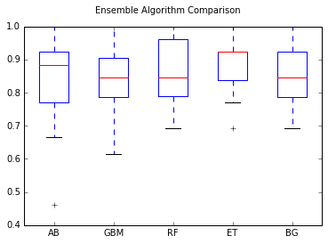

```python
# Compare Algorithms

fig = plt.figure()
fig.suptitle('Ensemble Algorithm Comparison')
ax = fig.add_subplot(111)
plt.boxplot(results)
ax.set_xticklabels(names)
plt.show()
```

#### [TOC](#TableOfContents#FinalizeSingeltonModelsSection)

## **Finalize Singelton Models**

> In this section we will finalize the model by **training it on the entire training dataset** and **make predictions for the hold-out validation dataset** to **confirm our findings**.

> A part of the findings was that **SVM performs better** when the **dataset is standardized** so that **all attributes have a mean value of zero** and a **standard deviation of one**.
- We can calculate this from the entire training dataset and apply the same transform to the input attributes from the validation dataset.

#### [TOC](#TableOfContents#FinalizeSingeltonModelsSection)

### **(1) LDA Model**

```python
# Scale the Input Data:

# Best: MEAN: 0.806202 using {'solver': 'svd'}


# Scale the input data
scaler = StandardScaler().fit(X_train)
rescaledX = scaler.transform(X_train)


# Model Construction
model_LDA = LinearDiscriminantAnalysis(solver='svd')


# Train (fit) the model
model_LDA.fit(rescaledX, Y_train)


# estimate accuracy on validation dataset
rescaledValidationX = scaler.transform(X_validation)
predictions = model_KNN.predict(rescaledValidationX)


# Display
print "Simple Accuracy Score: ", accuracy_score(Y_validation, predictions)
print "\n"
print "Confusion Matrix: \n", confusion_matrix(Y_validation, predictions)
print "\n"
print "Classification Report: \n", classification_report(Y_validation, predictions)

# Note: Leater Script -> UserWarning: Variables are collinear.
```

```
Simple Accuracy Score:  0.69696969697


Confusion Matrix:
[[21  5]
 [ 5  2]]


Classification Report:
             precision    recall  f1-score   support

        0.0       0.81      0.81      0.81        26
        1.0       0.29      0.29      0.29         7

avg / total       0.70      0.70      0.70        33
```

#### [TOC](#TableOfContents#FinalizeSingeltonModelsSection)

### **(2) KNN Model**

```python
# Prepare the KNN model
#
# Best: KFCV = 0.888889 using {'n_neighbors': 1}

# Scale the input data
scaler = StandardScaler().fit(X_train)
rescaledX = scaler.transform(X_train)

# Model Construction
model_KNN = KNeighborsClassifier(n_neighbors=1)

# Train (fit) the model
model_KNN.fit(rescaledX, Y_train)


# estimate accuracy on validation dataset
rescaledValidationX = scaler.transform(X_validation)
predictions = model_KNN.predict(rescaledValidationX)

# Display
print "Simple Accuracy Score: ", accuracy_score(Y_validation, predictions)
print "\n"
print "Confusion Matrix: \n", confusion_matrix(Y_validation, predictions)
print "\n"
print "Classification Report: \n", classification_report(Y_validation, predictions)
```

```
Simple Accuracy Score:  0.909090909091


Confusion Matrix:
[[23  3]
 [ 0  7]]


Classification Report:
             precision    recall  f1-score   support

        0.0       1.00      0.88      0.94        26
        1.0       0.70      1.00      0.82         7

avg / total       0.94      0.91      0.91        33
```

#### [TOC](#TableOfContents#FinalizeSingeltonModelsSection)

### **(3) SVM Model**

```python
# Prepare the SVM model
#
# Best: KFCV = 0.819444 using {'kernel': 'linear', 'C': 0.5}

# Scale the input data
scaler = StandardScaler().fit(X_train)
rescaledX = scaler.transform(X_train)

# Model Construction

# Variations of inputs

# model = SVC()
model_SVC = SVC(C=1.5)
# model = SVC(C=1.5, kernel='linear')

# Train (fit) the model
model_SVC.fit(rescaledX, Y_train)

# estimate accuracy on validation dataset
rescaledValidationX = scaler.transform(X_validation)
predictions = model_SVC.predict(rescaledValidationX)

# Display
print "Simple Accuracy Score: ", accuracy_score(Y_validation, predictions)
print "\n"
print "Confusion Matrix: \n", confusion_matrix(Y_validation, predictions)
print "\n"
print "Classification Report: \n", classification_report(Y_validation, predictions)
```

```
Simple Accuracy Score:  0.909090909091


Confusion Matrix:
[[26  0]
 [ 3  4]]


Classification Report:
             precision    recall  f1-score   support

        0.0       0.90      1.00      0.95        26
        1.0       1.00      0.57      0.73         7

avg / total       0.92      0.91      0.90        33
```

#### [TOC](#TableOfContents#FinalizeSingeltonModelsSection)

### **(4) CART MODEL**

```python
# Prepare the CART model

# Scale the input data
scaler = StandardScaler().fit(X_train)
rescaledX = scaler.transform(X_train)


# Model Construction

# Variations of inputs

model_DTC = DecisionTreeClassifier(criterion='gini', max_features='auto', min_samples_split=2,
                               splitter='random', class_weight= {1: 1} )

# Best: 0.937931 using {'max_features': 12, 'min_samples_split': 2, 'splitter': 'random',
#                       'criterion': 'gini', 'class_weight': {0: 0.5}}


# Best: 0.944828 using {'max_features': 'auto', 'min_samples_split': 3, 'splitter': 'best',
#                       'criterion': 'entropy', 'class_weight': {0: 0.5}}

# Best: 0.965278 using {'max_features': 'auto', 'min_samples_split': 2, 'splitter': 'random',
#                      'criterion': 'gini', 'class_weight': {1: 1}}

# Best: 0.965278 using {'max_features': 7, 'min_samples_split': 2, 'splitter': 'random',
#                      'criterion': 'entropy', 'class_weight': {0: 0.5}}


# Train (fit) the model
model_DTC.fit(rescaledX, Y_train)


# estimate accuracy on validation dataset
rescaledValidationX = scaler.transform(X_validation)
predictions = model_DTC.predict(rescaledValidationX)

# Display
print "Simple Accuracy Score: ", accuracy_score(Y_validation, predictions)
print "\n"
print "Confusion Matrix: \n", confusion_matrix(Y_validation, predictions)
print "\n"
print "Classification Report: \n", classification_report(Y_validation, predictions)
```

```
Simple Accuracy Score:  1.0


Confusion Matrix:
[[26  0]
 [ 0  7]]


Classification Report:
             precision    recall  f1-score   support

        0.0       1.00      1.00      1.00        26
        1.0       1.00      1.00      1.00         7

avg / total       1.00      1.00      1.00        33
```

#### [TOC](#TableOfContents#FinalizeEnsembleModelsSection)

## **Finalize Ensemble Models**

#### [TOC](#TableOfContents#FinalizeEnsembleModelsSection)

### **(1) Ensemble Method** - BaggingClassifier => DecisionTreeClassifier

```python
# Ensemble Method: Bagged Decision Trees for Classification => DecisionTreeClassifier

# Scale the input data
scaler = StandardScaler().fit(X_train)
rescaledX = scaler.transform(X_train)

# KFold Input constants
num_folds = 10
num_instances = len(X_train)
seed = 7
kfold = cross_validation.KFold(n=num_instances, n_folds=num_folds, random_state=seed)


# The CART contains the Tuned Parameters from previously (different runs produce different results)
#
# cart = DecisionTreeClassifier(criterion='entropy', max_features='auto', min_samples_split=3,
#                               splitter='best', class_weight= {0: 0.5} )
#
# cart = DecisionTreeClassifier()      # CLassifier : Decision Trees

cart = DecisionTreeClassifier(criterion='gini', max_features='auto', min_samples_split=2,
                               splitter='random', class_weight= {1: 1} )



# Model Bagging Classifier: => DecisionTreeClassifier
num_trees = 100                        # Num of Trees
model_BC = BaggingClassifier(base_estimator=cart, n_estimators=num_trees, random_state=seed)   # Model


# RESULTS
results = cross_validation.cross_val_score(model_BC, X_train, Y_train, cv=kfold)
print "Mean CrossValidation Score: ",results.mean()


# Simple Accuracy Calculations

# Running the example, we get a robust estimate of model accuracy.
model_BC.fit(rescaledX, Y_train)

# estimate accuracy on validation dataset
rescaledValidationX = scaler.transform(X_validation)
predictions = model_BC.predict(rescaledValidationX)

print "\n"
print "Simple Accuracy Score: ", accuracy_score(Y_validation, predictions)
print "\n"
print "Confusion Matrix: \n", confusion_matrix(Y_validation, predictions)
print "\n"
print "Classification Report: \n", classification_report(Y_validation, predictions)
```

```
Mean CrossValidation Score:  0.859615384615


Simple Accuracy Score:  1.0


Confusion Matrix:
[[26  0]
 [ 0  7]]


Classification Report:
             precision    recall  f1-score   support

        0.0       1.00      1.00      1.00        26
        1.0       1.00      1.00      1.00         7

avg / total       1.00      1.00      1.00        33
```

#### [TOC](#TableOfContents#FinalizeEnsembleModelsSection)

### **Grid Search For Tuning the ExtraTreesClassifier (ETC)**

> The **ExtraTreesClassifier** can really benefit from choosing the right values for key parameters and warrants a proper grid search to unearth a few sets of them.

```python
# Grid Search for ExtraTreesClassifier

# Parameter List Construction:

n_estimators_values  = [6,8,10,12,14]
criterion_values = ['gini', 'entropy']
min_samples_split_values = [1, 2, 3, 4]
max_features_values = [7, 9, 12, 'auto', 'sqrt', 'log2']
class_weight_values = [{1: 1} , {0: .5}]


# Grid
param_grid = dict(criterion=criterion_values,min_samples_split=min_samples_split_values,n_estimators=n_estimators_values,
                 max_features=max_features_values,class_weight=class_weight_values)

# Model
model_ETC = ExtraTreesClassifier()

# KFold Input constants
num_folds = 10
num_instances = len(X_train)
seed = 7

# KFOLD Validation:
kfold = cross_validation.KFold(n=num_instances, n_folds=num_folds, random_state=seed)
grid = GridSearchCV(estimator=model_ETC, param_grid=param_grid, scoring=scoring, cv=kfold)
grid_result = grid.fit(rescaledX, Y_train)


# OutPut Results:
print("Best: %f using %s" % (grid_result.best_score_, grid_result.best_params_)), "\n"
for params, mean_score, scores in grid_result.grid_scores_:
    print("%f (%f) with: %r" % (scores.mean(), scores.std(), params))


# SIMPLE ACCURACY SCORE
model_ETC.fit(rescaledX, Y_train)
# estimate accuracy on validation dataset
rescaledValidationX = scaler.transform(X_validation)
predictions = model_ETC.predict(rescaledValidationX)
print "\nSimple Accuracy Score: ", accuracy_score(Y_validation, predictions)
```

```
Best: 0.914729 using {'max_features': 'log2', 'min_samples_split': 2, 'n_estimators': 12, 'criterion': 'gini', 'class_weight': {1: 1}}

0.851923 (0.095788) with: {'max_features': 7, 'min_samples_split': 1, 'n_estimators': 6, 'criterion': 'gini', 'class_weight': {1: 1}}
0.883333 (0.086659) with: {'max_features': 7, 'min_samples_split': 1, 'n_estimators': 8, 'criterion': 'gini', 'class_weight': {1: 1}}
0.867949 (0.109396) with: {'max_features': 7, 'min_samples_split': 1, 'n_estimators': 10, 'criterion': 'gini', 'class_weight': {1: 1}}
0.867308 (0.093601) with: {'max_features': 7, 'min_samples_split': 1, 'n_estimators': 12, 'criterion': 'gini', 'class_weight': {1: 1}}
0.859615 (0.085160) with: {'max_features': 7, 'min_samples_split': 1, 'n_estimators': 14, 'criterion': 'gini', 'class_weight': {1: 1}}
0.875000 (0.117055) with: {'max_features': 7, 'min_samples_split': 2, 'n_estimators': 6, 'criterion': 'gini', 'class_weight': {1: 1}}
0.875000 (0.122006) with: {'max_features': 7, 'min_samples_split': 2, 'n_estimators': 8, 'criterion': 'gini', 'class_weight': {1: 1}}
0.851923 (0.107434) with: {'max_features': 7, 'min_samples_split': 2, 'n_estimators': 10, 'criterion': 'gini', 'class_weight': {1: 1}}
0.890385 (0.106744) with: {'max_features': 7, 'min_samples_split': 2, 'n_estimators': 12, 'criterion': 'gini', 'class_weight': {1: 1}}
0.875000 (0.111886) with: {'max_features': 7, 'min_samples_split': 2, 'n_estimators': 14, 'criterion': 'gini', 'class_weight': {1: 1}}
0.899359 (0.069044) with: {'max_features': 7, 'min_samples_split': 3, 'n_estimators': 6, 'criterion': 'gini', 'class_weight': {1: 1}}
0.867949 (0.103846) with: {'max_features': 7, 'min_samples_split': 3, 'n_estimators': 8, 'criterion': 'gini', 'class_weight': {1: 1}}
0.899359 (0.048991) with: {'max_features': 7, 'min_samples_split': 3, 'n_estimators': 10, 'criterion': 'gini', 'class_weight': {1: 1}}
0.859615 (0.091846) with: {'max_features': 7, 'min_samples_split': 3, 'n_estimators': 12, 'criterion': 'gini', 'class_weight': {1: 1}}
0.866667 (0.118505) with: {'max_features': 7, 'min_samples_split': 3, 'n_estimators': 14, 'criterion': 'gini', 'class_weight': {1: 1}}
0.859615 (0.109480) with: {'max_features': 7, 'min_samples_split': 4, 'n_estimators': 6, 'criterion': 'gini', 'class_weight': {1: 1}}
0.882692 (0.136104) with: {'max_features': 7, 'min_samples_split': 4, 'n_estimators': 8, 'criterion': 'gini', 'class_weight': {1: 1}}
0.860256 (0.090009) with: {'max_features': 7, 'min_samples_split': 4, 'n_estimators': 10, 'criterion': 'gini', 'class_weight': {1: 1}}
0.828846 (0.091199) with: {'max_features': 7, 'min_samples_split': 4, 'n_estimators': 12, 'criterion': 'gini', 'class_weight': {1: 1}}
0.867949 (0.114677) with: {'max_features': 7, 'min_samples_split': 4, 'n_estimators': 14, 'criterion': 'gini', 'class_weight': {1: 1}}
0.875000 (0.088231) with: {'max_features': 9, 'min_samples_split': 1, 'n_estimators': 6, 'criterion': 'gini', 'class_weight': {1: 1}}
0.868590 (0.076883) with: {'max_features': 9, 'min_samples_split': 1, 'n_estimators': 8, 'criterion': 'gini', 'class_weight': {1: 1}}
0.891026 (0.086432) with: {'max_features': 9, 'min_samples_split': 1, 'n_estimators': 10, 'criterion': 'gini', 'class_weight': {1: 1}}
0.867308 (0.099722) with: {'max_features': 9, 'min_samples_split': 1, 'n_estimators': 12, 'criterion': 'gini', 'class_weight': {1: 1}}
0.866667 (0.123397) with: {'max_features': 9, 'min_samples_split': 1, 'n_estimators': 14, 'criterion': 'gini', 'class_weight': {1: 1}}
0.874359 (0.114354) with: {'max_features': 9, 'min_samples_split': 2, 'n_estimators': 6, 'criterion': 'gini', 'class_weight': {1: 1}}
0.859615 (0.085160) with: {'max_features': 9, 'min_samples_split': 2, 'n_estimators': 8, 'criterion': 'gini', 'class_weight': {1: 1}}
0.875641 (0.092814) with: {'max_features': 9, 'min_samples_split': 2, 'n_estimators': 10, 'criterion': 'gini', 'class_weight': {1: 1}}
0.867308 (0.093601) with: {'max_features': 9, 'min_samples_split': 2, 'n_estimators': 12, 'criterion': 'gini', 'class_weight': {1: 1}}
0.867949 (0.097983) with: {'max_features': 9, 'min_samples_split': 2, 'n_estimators': 14, 'criterion': 'gini', 'class_weight': {1: 1}}
0.883333 (0.093238) with: {'max_features': 9, 'min_samples_split': 3, 'n_estimators': 6, 'criterion': 'gini', 'class_weight': {1: 1}}
0.859615 (0.103935) with: {'max_features': 9, 'min_samples_split': 3, 'n_estimators': 8, 'criterion': 'gini', 'class_weight': {1: 1}}
0.867949 (0.085051) with: {'max_features': 9, 'min_samples_split': 3, 'n_estimators': 10, 'criterion': 'gini', 'class_weight': {1: 1}}
0.851282 (0.104344) with: {'max_features': 9, 'min_samples_split': 3, 'n_estimators': 12, 'criterion': 'gini', 'class_weight': {1: 1}}
0.860256 (0.090009) with: {'max_features': 9, 'min_samples_split': 3, 'n_estimators': 14, 'criterion': 'gini', 'class_weight': {1: 1}}
0.867308 (0.105489) with: {'max_features': 9, 'min_samples_split': 4, 'n_estimators': 6, 'criterion': 'gini', 'class_weight': {1: 1}}
0.866667 (0.123397) with: {'max_features': 9, 'min_samples_split': 4, 'n_estimators': 8, 'criterion': 'gini', 'class_weight': {1: 1}}
0.876282 (0.050478) with: {'max_features': 9, 'min_samples_split': 4, 'n_estimators': 10, 'criterion': 'gini', 'class_weight': {1: 1}}
```

[output cut: 429 more lines]

```
0.891026 (0.093026) with: {'max_features': 'log2', 'min_samples_split': 2, 'n_estimators': 10, 'criterion': 'entropy', 'class_weight': {0: 0.5}}
0.875000 (0.100755) with: {'max_features': 'log2', 'min_samples_split': 2, 'n_estimators': 12, 'criterion': 'entropy', 'class_weight': {0: 0.5}}
0.883333 (0.093238) with: {'max_features': 'log2', 'min_samples_split': 2, 'n_estimators': 14, 'criterion': 'entropy', 'class_weight': {0: 0.5}}
0.883974 (0.098578) with: {'max_features': 'log2', 'min_samples_split': 3, 'n_estimators': 6, 'criterion': 'entropy', 'class_weight': {0: 0.5}}
0.867308 (0.105489) with: {'max_features': 'log2', 'min_samples_split': 3, 'n_estimators': 8, 'criterion': 'entropy', 'class_weight': {0: 0.5}}
0.875000 (0.106466) with: {'max_features': 'log2', 'min_samples_split': 3, 'n_estimators': 10, 'criterion': 'entropy', 'class_weight': {0: 0.5}}
0.891026 (0.099183) with: {'max_features': 'log2', 'min_samples_split': 3, 'n_estimators': 12, 'criterion': 'entropy', 'class_weight': {0: 0.5}}
0.875641 (0.110294) with: {'max_features': 'log2', 'min_samples_split': 3, 'n_estimators': 14, 'criterion': 'entropy', 'class_weight': {0: 0.5}}
0.875000 (0.094701) with: {'max_features': 'log2', 'min_samples_split': 4, 'n_estimators': 6, 'criterion': 'entropy', 'class_weight': {0: 0.5}}
0.890385 (0.106744) with: {'max_features': 'log2', 'min_samples_split': 4, 'n_estimators': 8, 'criterion': 'entropy', 'class_weight': {0: 0.5}}
0.860256 (0.075728) with: {'max_features': 'log2', 'min_samples_split': 4, 'n_estimators': 10, 'criterion': 'entropy', 'class_weight': {0: 0.5}}
0.866667 (0.113402) with: {'max_features': 'log2', 'min_samples_split': 4, 'n_estimators': 12, 'criterion': 'entropy', 'class_weight': {0: 0.5}}
0.843590 (0.117753) with: {'max_features': 'log2', 'min_samples_split': 4, 'n_estimators': 14, 'criterion': 'entropy', 'class_weight': {0: 0.5}}

Simple Accuracy Score:  0.969696969697
```

#### [TOC](#TableOfContents#FinalizeEnsembleModelsSection)

### **(2) Ensemble Method** - ExtraTreesClassifier => KNN

```python
# Ensemble Method: Extra Trees Classification => KNN


# Scale the input data
scaler = StandardScaler().fit(X_train)
rescaledX = scaler.transform(X_train)


# KFold Input constants
num_folds = 10
num_instances = len(X_train)
seed = 7
kfold = cross_validation.KFold(n=num_instances, n_folds=num_folds, random_state=seed)


# knn = KNeighborsClassifier()
#
# Best: 0.888889 using {'n_neighbors': 1}

knn = KNeighborsClassifier(n_neighbors=1)   # Classifier: KNN



# Model: Extra Trees Classifier parameters
num_trees = 100
max_features = 7
min_sam_split = 2



# model_ETC = ExtraTreesClassifier(n_estimators=num_trees, max_features=max_features, min_samples_split=min_sam_split)

# GRID SEARCH - Best: 0.987342 using {'max_features': 9, 'min_samples_split': 1, 'n_estimators': 12,
#       'criterion': 'entropy', 'class_weight': {1: 1}}
#
# Best: 0.930233 using {'max_features': 'sqrt', 'min_samples_split': 2, 'n_estimators': 6, 'criterion':
#                      'gini', 'class_weight': {0: 0.5}}


# model_ETC = ExtraTreesClassifier(n_estimators=12, max_features=9, min_samples_split=1, criterion='entropy', class_weight={1: 1} )

model_ETC = ExtraTreesClassifier(n_estimators=6, max_features='sqrt', min_samples_split=2,
                                 criterion='gini', class_weight={0: 0.5} )



# RESULTS
results = cross_validation.cross_val_score(model_ETC, X_train, Y_train, cv=kfold)
print "Mean CrossValidation Score: ",results.mean()

# Running the example provides a mean estimate of classification accuracy.



# Simple Accuracy Calculations

# Running the example, we get a robust estimate of model accuracy.
model_ETC.fit(rescaledX, Y_train)

# estimate accuracy on validation dataset
rescaledValidationX = scaler.transform(X_validation)
predictions = model_ETC.predict(rescaledValidationX)

print "\n"
print "Simple Accuracy Score: ", accuracy_score(Y_validation, predictions)
print "\n"
print "Confusion Matrix: \n", confusion_matrix(Y_validation, predictions)
print "\n"
print "Classification Report: \n", classification_report(Y_validation, predictions)
```

```
Mean CrossValidation Score:  0.883333333333


Simple Accuracy Score:  0.969696969697


Confusion Matrix:
[[25  1]
 [ 0  7]]


Classification Report:
             precision    recall  f1-score   support

        0.0       1.00      0.96      0.98        26
        1.0       0.88      1.00      0.93         7

avg / total       0.97      0.97      0.97        33
```

The following **performance measures** that can give more insight into the accuracy of the model than traditional **classification accuracy**:

- **Confusion Matrix:** A breakdown of predictions into a table showing **correct** predictions (the **diagonal**) and the types of **incorrect** predictions made (what classes incorrect predictions were assigned).
- **Precision:** A measure of a classifiers exactness.
- **Recall:** A measure of a classifiers completeness
- **F1 Score (or F-score):** A weighted average of precision and recall.

#### [TOC](#TableOfContents#SaveTestCommunicateDescription)

# Task 6 - Dump Classifier & Supporting Data

#### [TOC](#TableOfContents#SaveTestCommunicateDescription)

### RE-Transpose DF to prepare it for Transformation into Python Dictionary

```python
# Re-Transpose DF to original form to prepare it for Transformation into Python Dictionary

reverted_df = over_sampled_df.T
```

```python
# Spot Check - New Columns on the end (0 ->17) Visual Confirmation

# reverted_df
```

```python
# Spot Check - Shape

reverted_df.shape
```

```
(21, 162)
```

```python
# Transform Transposed DF into Python Dictionary
# Here we COULD lose data because of duplicate Colums with the same name so we make sure they are all unique.

reverted_dict = reverted_df.to_dict()
```

```python
# Spot Check:

# reverted_dict
```

```python
### Store to my_dataset for easy export below.
#
# my_dataset = data_dict

my_dataset = reverted_dict
```

#### [TOC](#TableOfContents#SaveTestCommunicateDescription)

### **Dump Data**

- **NOTE** - As a courtesy to the reader, a link to the **Load Data To Be Tested section** is here: Load Data To Be Tested Section
- **NOTE** - As a courtesy to the reader, a link to the **Test Classifier Results Section** is here: Test Classifier Results Section

```python
### Task 6: Dump your classifier, dataset, and features_list so anyone can
### check your results. You do not need to change anything below, but make sure
### that the version of poi_id.py that you submit can be run on its own and
### generates the necessary .pkl files for validating your results.

# Various Saves of the Models valuated by the test script - Uncomment the classifier to be dumped.

# FORM: clf = model
# clf = model_ETC       # ExtraTreesClassifier => KNN
# clf = model_BC        # BaggingClassifier => DecisionTreeClassifier
# clf = model_DTC       # DecisionTreeClassifier
clf = model_SVC       # SupportVectorClassifier
# clf = model_KNN       # KNeighborsClassifier
# clf = model_LDA       # LinearDiscriminantAnalysis



# Dump the Classifier, Dataset, and Features List)
#
dump_classifier_and_data(clf, my_dataset, features_list)
```

#### [TOC](#TableOfContents#TesterCodeSection)

# Tester Code Section

#### [TOC](#TableOfContents#TesterCodeSection)

### (1) Load Test Algorithm

> This next cell loads the testing code, it only needs to be run once, there is not output.

```python
#!/usr/bin/pickle

""" a basic script for importing student's POI identifier,
    and checking the results that they get from it

    requires that the algorithm, dataset, and features list
    be written to my_classifier.pkl, my_dataset.pkl, and
    my_feature_list.pkl, respectively

    that process should happen at the end of poi_id.py
"""

import pickle
import sys
from sklearn.cross_validation import StratifiedShuffleSplit
sys.path.append("../tools/")
from feature_format import featureFormat, targetFeatureSplit



PERF_FORMAT_STRING = "\
\tAccuracy: {:>0.{display_precision}f}\tPrecision: {:>0.{display_precision}f}\t\
Recall: {:>0.{display_precision}f}\tF1: {:>0.{display_precision}f}\tF2: {:>0.{display_precision}f}"
RESULTS_FORMAT_STRING = "\tTotal predictions: {:4d}\tTrue positives: {:4d}\tFalse positives: {:4d}\
\tFalse negatives: {:4d}\tTrue negatives: {:4d}"



def test_classifier(clf, dataset, feature_list, folds = 1000):
    data = featureFormat(dataset, feature_list, sort_keys = True)
    labels, features = targetFeatureSplit(data)
    cv = StratifiedShuffleSplit(labels, folds, random_state = 42)
    true_negatives = 0
    false_negatives = 0
    true_positives = 0
    false_positives = 0
    for train_idx, test_idx in cv:
        features_train = []
        features_test  = []
        labels_train   = []
        labels_test    = []
        for ii in train_idx:
            features_train.append( features[ii] )
            labels_train.append( labels[ii] )
        for jj in test_idx:
            features_test.append( features[jj] )
            labels_test.append( labels[jj] )

        ### fit the classifier using training set, and test on test set
        clf.fit(features_train, labels_train)
        predictions = clf.predict(features_test)
        for prediction, truth in zip(predictions, labels_test):
            if prediction == 0 and truth == 0:
                true_negatives += 1
            elif prediction == 0 and truth == 1:
                false_negatives += 1
            elif prediction == 1 and truth == 0:
                false_positives += 1
            elif prediction == 1 and truth == 1:
                true_positives += 1
            else:
                print "Warning: Found a predicted label not == 0 or 1."
                print "All predictions should take value 0 or 1."
                print "Evaluating performance for processed predictions:"
                break
    try:
        total_predictions = true_negatives + false_negatives + false_positives + true_positives
        accuracy = 1.0*(true_positives + true_negatives)/total_predictions
        precision = 1.0*true_positives/(true_positives+false_positives)
        recall = 1.0*true_positives/(true_positives+false_negatives)
        f1 = 2.0 * true_positives/(2*true_positives + false_positives+false_negatives)
        f2 = (1+2.0*2.0) * precision*recall/(4*precision + recall)
        print clf
        print PERF_FORMAT_STRING.format(accuracy, precision, recall, f1, f2, display_precision = 5)
        print RESULTS_FORMAT_STRING.format(total_predictions, true_positives, false_positives, false_negatives, true_negatives)
        print ""
    except:
        print "Got a divide by zero when trying out:", clf
        print "Precision or recall may be undefined due to a lack of true positive predicitons."



CLF_PICKLE_FILENAME = "my_classifier.pkl"
DATASET_PICKLE_FILENAME = "my_dataset.pkl"
FEATURE_LIST_FILENAME = "my_feature_list.pkl"



def dump_classifier_and_data(clf, dataset, feature_list):
    with open(CLF_PICKLE_FILENAME, "w") as clf_outfile:
        pickle.dump(clf, clf_outfile)
    with open(DATASET_PICKLE_FILENAME, "w") as dataset_outfile:
        pickle.dump(dataset, dataset_outfile)
    with open(FEATURE_LIST_FILENAME, "w") as featurelist_outfile:
        pickle.dump(feature_list, featurelist_outfile)



def load_classifier_and_data():
    with open(CLF_PICKLE_FILENAME, "r") as clf_infile:
        clf = pickle.load(clf_infile)
    with open(DATASET_PICKLE_FILENAME, "r") as dataset_infile:
        dataset = pickle.load(dataset_infile)
    with open(FEATURE_LIST_FILENAME, "r") as featurelist_infile:
        feature_list = pickle.load(featurelist_infile)
    return clf, dataset, feature_list
```

#### [TOC](#TableOfContents#TesterCodeSection)

### (2) Load the Data to be tested

> This code loads up the classifier, dataset, and feature_list
- **NOTE:** - this code should be run **each time** a new classifier is dumped in order for it to be evaluated
- **NOTE** - As a courtesy to the reader, a link to the **dump data section** is here: Dump Data Section

```python
### load up the classifier, dataset, and feature_list

clf, dataset, feature_list = load_classifier_and_data()
```

#### [TOC](#TableOfContents#TesterCodeSection)

### (3) Spot Check: Examine the type of classifier being evaluated

> This spot check prints out the name of the classifier being evaluated and **can be run each time a new classifier is being tested** to you know what particular classifier is undergoing examination.

```python
type(clf)
```

```
sklearn.svm.classes.SVC
```

#### [TOC](#TableOfContents#TesterCodeSection)

### (4) Test Classifier and Results

> This is the code which actually runs the testing procedures. It will run the tests and display thre results. **It should be run again for each classifier loaded previously.**
- **NOTE** - As a courtesy to the reader, a link to the **dump data section** is here: Dump Data Section

```python
### Run testing script
test_classifier(clf, dataset, feature_list)
```

```
ExtraTreesClassifier(bootstrap=False, class_weight={0: 0.5}, criterion='gini',
           max_depth=None, max_features='sqrt', max_leaf_nodes=None,
           min_samples_leaf=1, min_samples_split=2,
           min_weight_fraction_leaf=0.0, n_estimators=6, n_jobs=1,
           oob_score=False, random_state=None, verbose=0, warm_start=False)
	Accuracy: 0.95935	Precision: 0.90364	Recall: 0.92600	F1: 0.91468	F2: 0.92144
	Total predictions: 17000	True positives: 3704	False positives:  395	False negatives:  296	True negatives: 12605
```

```python
### Run testing script
test_classifier(clf, dataset, feature_list)
```

```
BaggingClassifier(base_estimator=DecisionTreeClassifier(class_weight={1: 1}, criterion='gini', max_depth=None,
            max_features='auto', max_leaf_nodes=None, min_samples_leaf=1,
            min_samples_split=2, min_weight_fraction_leaf=0.0,
            presort=False, random_state=None, splitter='random'),
         bootstrap=True, bootstrap_features=False, max_features=1.0,
         max_samples=1.0, n_estimators=100, n_jobs=1, oob_score=False,
         random_state=7, verbose=0, warm_start=False)
	Accuracy: 0.95541	Precision: 0.88504	Recall: 0.93150	F1: 0.90767	F2: 0.92182
	Total predictions: 17000	True positives: 3726	False positives:  484	False negatives:  274	True negatives: 12516
```

```python
### Run testing script
test_classifier(clf, dataset, feature_list)
```

```
DecisionTreeClassifier(class_weight={1: 1}, criterion='gini', max_depth=None,
            max_features='auto', max_leaf_nodes=None, min_samples_leaf=1,
            min_samples_split=2, min_weight_fraction_leaf=0.0,
            presort=False, random_state=None, splitter='random')
	Accuracy: 0.90271	Precision: 0.72566	Recall: 0.94300	F1: 0.82018	F2: 0.88971
	Total predictions: 17000	True positives: 3772	False positives: 1426	False negatives:  228	True negatives: 11574
```

```python
### Run testing script
test_classifier(clf, dataset, feature_list)
```

```
KNeighborsClassifier(algorithm='auto', leaf_size=30, metric='minkowski',
           metric_params=None, n_jobs=1, n_neighbors=1, p=2,
           weights='uniform')
	Accuracy: 0.89947	Precision: 0.71957	Recall: 0.93850	F1: 0.81458	F2: 0.88467
	Total predictions: 17000	True positives: 3754	False positives: 1463	False negatives:  246	True negatives: 11537
```

```python
### Run testing script
test_classifier(clf, dataset, feature_list)
```

```
SVC(C=1.5, cache_size=200, class_weight=None, coef0=0.0,
  decision_function_shape=None, degree=3, gamma='auto', kernel='rbf',
  max_iter=-1, probability=False, random_state=None, shrinking=True,
  tol=0.001, verbose=False)
	Accuracy: 0.98012	Precision: 1.00000	Recall: 0.91550	F1: 0.95589	F2: 0.93124
	Total predictions: 17000	True positives: 3662	False positives:    0	False negatives:  338	True negatives: 13000
```

```python
### Run testing script
test_classifier(clf, dataset, feature_list)
```

```
LinearDiscriminantAnalysis(n_components=None, priors=None, shrinkage=None,
              solver='svd', store_covariance=False, tol=0.0001)
	Accuracy: 0.78988	Precision: 0.59477	Recall: 0.33575	F1: 0.42921	F2: 0.36778
	Total predictions: 17000	True positives: 1343	False positives:  915	False negatives: 2657	True negatives: 12085
```

#### [TOC](#TableOfContents#TesterCodeSection)

### (4) Results Summary

> This is a table summary of the scores of each classifier examined for ease of evaluation.

| Classifier | Accuracy | Precision | Recall | F1 | F2 |
| --- | --- | --- | --- | --- | --- |
| SVC | 0.98012 | 1.00000 | 0.91550 | 0.95589 | 0.93124 |
| ExtraTreesClassifier->KNN | 0.95935 | 0.90364 | 0.92600 | 0.91468 | 0.92144 |
| BaggingClassifier->DTC | 0.95541 | 0.88504 | 0.93150 | 0.90767 | 0.92182 |
| DecisionTreeClassifier | 0.90271 | 0.72566 | 0.94300 | 0.82018 | 0.88971 |
| KNeighborsClassifier | 0.89947 | 0.71957 | 0.93850 | 0.81458 | 0.88467 |
| LinearDiscriminantAnalysis | 0.78988 | 0.59477 | 0.33575 | 0.42921 | 0.36778 |

#### [TOC](#TableOfContents#DocumentationQuestions)

# Documentation Questions and Answers Section

#### [TOC](#TableOfContents#DocumentationQuestions)

### Question # 1

(1) Summarize for us the **goal of this project** and how machine learning is useful in trying to accomplish it. As part of your answer, give some **background on the dataset** and how it can be used to answer the project question. Were there any **outliers** in the data when you got it, and how did you handle those?

> [relevant rubric items: “data exploration”, “outlier investigation”]

### Answer # 1

The goal of this project is to detect additional bad guys (aka "persons of interest", POI) by using the Enron data to create a Machine Learning Classifier of a POI which is capable of detecting new POI's with verifiable measures of accuracy, precision, and recall.

> Relevant Link: Project Background

The dataset contains email, financial, and labels (indicating POI's) data. The idea is that there is enough multi-dimmensional information contained in those features (and newly engineered ones) to accurately classify new POI's based upon the features of the already classified POI's. Many of the fields required transformation to be useful.

> Relevant Link: Quick Data Anlysis One Section

There were most definitely outliers (2) which were removed (dropped entirely from the dataset) to enhance the accuracy of the classifier.

> Relevant Link: Outlier Detection & Removal Section

#### [TOC](#TableOfContents#DocumentationQuestions)

### Question # 2

(2) What **features** did you end up using in your POI identifier, and what **selection process** did you use to pick them? Did you have to do any **scaling**? Why or why not? As part of the assignment, you should attempt to **engineer your own feature** that does not come ready-made in the dataset -- **explain** what feature you tried to make, and the **rationale** behind it. (You do not necessarily have to use it in the final analysis, only engineer and test it.) In your **feature selection step**, if you used an algorithm like a decision tree, please also give the feature importances of the features that you use, and if you used an **automated feature** selection function like SelectKBest, please **report the feature scores** and **reasons** for your choice of parameter values.

> [relevant rubric items: “create new features”, “properly scale features”, “intelligently select feature”]

### Answer # 2

The 15 features used are listed below **(in bold)**, I interrogated two **automated feature selectors** (Select **KBest** and **Recursive Feature Elimination**), and settled on **SelectKBest** because it provided results which seemed more intuitive.

I provide an analysis of which 15 features were chosen, and the methodology deployed for feature selection below. All of this comes over the backdrop of using an **Esemble Algorithm of ExtraTreesClassifier->KNN** as the algorithm the POI tester script evaluates.

Additionally, all Precision / Recall results are from runs of the POI script results.

The ranked KBest feature scores are also listed as well as a plot of the precision / recall results used in he selection process.

In the end the nuances of performance were very subtle as they all performed fairly well. I settled on the 15 selected KBest features listed below because they performed the best with the fewest features. I could have gone with far fewer feature without a significant performance hit, but in the interest of having the best possible precision/recall scores I settled on the 15 chosen which provided a Precision of **0.89709**, and a Recall of **0.92400**.

> Relevant Link: Automated Feature Selection Section

### **KBest:** ( 15 Influential Attributes Chosen)

**15 Selected Features (in bold)** and DataFrame Column Ordering:

- 1 '**bonus**',
- 2 '**deferral_payments**',
- 3 '**deferred_income**',
- 4 '**director_fees**',
- 5 'email_address',
- 6 '**exercised_stock_options**',
- 7 '**expenses**',
- 8 'from_messages',
- 9 'from_poi_to_this_person',
- 10 'from_this_person_to_poi',
- 11 '**loan_advances**',
- 12 '**long_term_incentive**',
- 13 '**other**',
- 14 '**restricted_stock**',
- 15 '**restricted_stock_deferred**',
- 16 '**salary**',
- 17 '**shared_receipt_with_poi**',
- 18 'to_messages',
- 19 '**total_payments**',
- 20 '**total_stock_value**',

**Engineered Features:**

- 21 ratio_to',
- 22 'ratio_from',
- 23 'big_shot',

**Class Label**

- 24 'poi'

### Precision & Recall Results from POI Tester

**at various (Select KBest ) Feature Levels**

> Including Winner

| Run # | K | PRECISION | RECALL |  |
| --- | --- | --- | --- | --- |
| 1 | 1 | 0.71340 | 0.92350 |  |
| 2 | 3 | 0.85965 | 0.93250 |  |
| 3 | 6 | 0.89060 | 0.92600 |  |
| 4 | 9 | 0.87826 | 0.92700 |  |
| 5 | 12 | 0.88311 | 0.92550 |  |
| 6 | 15 | 0.89709 | 0.92400 | **<- Winner** |
| 7 | 18 | 0.89402 | 0.93000 |  |
| 8 | 20 | 0.89722 | 0.92750 |  |

### Ranked Select K Best Scores per feature

[output not shown]

**Plot Analysis**

> There were 8 runs of the POI tester script using features chosen by the Select K Best Algorithm using values of: [1,3,6,9,12,15,18,20]. Those runs provided Precision and Recall values which are graphed below. The POI script was using the Esemble Algorithm of ExtraTreesClassifier->KNN which generated the Precision and Recall values.
- The recall is quite good consistenly, and the precision seems to level off at around the 15 feature mark (best performance w/fewest features).

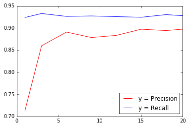

```python
# Precision & Recall Plot from POI Tester Runs of various Features from Select K Best

import matplotlib.pyplot as plt
import numpy as np

# Precision values for K=1,3,6,9,12,15,18,20
x = np.array([0.71340, 0.85965, 0.89060, 0.87826, 0.88311, 0.89709, 0.89402, 0.89722])

# Recall values for K=1,3,6,9,12,15,18,20
y = np.array([0.92350, 0.93250, 0.92600, 0.92700, 0.92550, 0.92400, 0.93000, 0.92750])

# Values of K (Features selected via KBest)
z = np.array([1, 3, 6, 9, 12, 15, 18, 20])

plt.gca().set_color_cycle(['red', 'blue'])

plt.plot(z, x)
plt.plot(z, y)

plt.legend(['y = Precision', 'y = Recall'], loc='lower right')

plt.show()
```

**Input Data Scaling** was required since the means and units of the data were highly disimilar.

> The input featuers had **differing distributions** of the raw data which could **negatively impacting** the performance of some of the classificationalgorithms, so I scale the input to a standard.
> - Since I intended to be an apples to apples comparison, I used feature scaling even if a couple of the algorithms might not absolutely require it (aka : DecisionTreeClassifier), although most did call for scaling. This process was continued into the Ensemble Classifiers as well for the following:
> > - BaggingClassifier => DecisionTreeClassifier
> > - ExtraTreesClassifier => KNN

Although most algorithms will benefit from scaling, such as:

> > LogisticRegression

> > LinearDiscriminantAnalysis

> > KNeighborsClassifier

> > GaussianNB

> > SVC
- there are some that don't speciically require it:

  > > DecisionTreeClassifier

> Input scaling is where the data is **transformed** such that each attribute has a **mean value of zero** and a **standard deviation of one**.
- That way we can get a **fair estimation** of how each model with standardized data might perform on unseen data.

> Relevant Link: Anlysis One Section

> Relevant Link: Standardized Data Section

Although **Engineered Features** were **not** used, I invented three: **ratio_to**, **ratio_from**, and **big_shot**.

> Relevant Link: Feature Engineering Section
- **Rationale:** - The two features "**ratio_to**" and "**ratio_from**" were 'gimmies' from the lectures (which also happened to make good sense and inject useful information to the classification process).

I also enginnered a third feature called "**big_shot**", which was a numerical feature that combined the qualities of "Highly Paid" and "High Net Worth".

This intuitive feature suggests that POI's probably shared a good number of features (and magnitude) inherent in a "Big Shot" which would help better classify them in new (unseen) data.

> Relevant Link: Create New Features Section

> Relevant Link: Intuition Features Justification Section

**IMPACT - Pre / Post Feature Engineering Results**

> As evidenced below (in all of the algorithms considered), there really was **no significant** positive (or negative) impact of the engineered features; and in some cases there was a slight positive impact, in others a slight negative impact, but nothing major.

| Classifier | Precision (Pre) | Precision (Post) | Recall (Pre) | Recall (Post) |
| --- | --- | --- | --- | --- |
| SVC | 1.00000 | 1.00000 | 0.91550 | 0.91550 |
| ExtraTreesClassifier->KNN | 0.90364 | 0.89097 | 0.92600 | 0.92750 |
| BaggingClassifier->DTC | 0.88504 | 0.88206 | 0.93150 | 0.90682 |
| DecisionTreeClassifier | 0.72566 | 0.71477 | 0.94300 | 0.94100 |
| KNeighborsClassifier | 0.71957 | 0.74774 | 0.93850 | 0.92850 |
| LinearDiscriminantAnalysis | 0.59477 | 0.62015 | 0.33575 | 0.32775 |

#### [TOC](#TableOfContents#DocumentationQuestions)

### Question # 3

(3) What **algorithm** did you end up using? What other one(s) did you try? How did **model performance differ between algorithms**?

> [relevant rubric item: “pick an algorithm”]

### Answer # 3

I had evaluated a number of single classifiers and ensemble classifiers (summarized below), and finally settled on an Ensemble Classifier **ExtraTreesClassifier->KNN** although it was nearly indistinguishable in term of performance from the other Ensemble Classifier BaggingClassifier->DTC.

I decided to **not** choose the SVC classifier because it appeared to me to be too accurate and I suspect it was simply memorizing the data. The other algorithms performed well, just not as well.

### Performance of differenct classifiers per the Test Script:

| Classifier | Accuracy | Precision | Recall | F1 | F2 |
| --- | --- | --- | --- | --- | --- |
| SVC | 0.98012 | 1.00000 | 0.91550 | 0.95589 | 0.93124 |
| ExtraTreesClassifier->KNN | 0.95935 | 0.90364 | 0.92600 | 0.91468 | 0.92144 |
| BaggingClassifier->DTC | 0.95541 | 0.88504 | 0.93150 | 0.90767 | 0.92182 |
| DecisionTreeClassifier | 0.90271 | 0.72566 | 0.94300 | 0.82018 | 0.88971 |
| KNeighborsClassifier | 0.89947 | 0.71957 | 0.93850 | 0.81458 | 0.88467 |
| LinearDiscriminantAnalysis | 0.78988 | 0.59477 | 0.33575 | 0.42921 | 0.36778 |

**NOTE:** - The various algorithms were benchmarked in a number of ways and evaluated similarily outside of the test scripts which were both instructional and telling. The links below provide the details for exactly how that process was executed and the corresponding results.

> Relevant Link: Evaluate Classifiers Section

> Relevant Link: Compare Baseline Algorithms Section

> Relevant Link: Compare Baseline Algorithms Analysis Section

> Relevant Link:Finalize Singelton Models Section

> > Relevant Link: * Finalize LDA Section

> > Relevant Link: * Finalize KNN Section

> > Relevant Link: * Finalize SVN Section

> > Relevant Link: * Finalize CART Section

> Relevant Link:Finalize Ensemble Models Section

> > Relevant Link: * Finalize EnsembleBagging Section

> > Relevant Link: * Grid Search ExtraTrees Section

> > Relevant Link: * Finalize Ensemble ExtraTrees Section

#### [TOC](#TableOfContents#DocumentationQuestions)

### Question # 4

(4) What does it mean to **tune the parameters** of an algorithm, and what can happen **if you don’t do this well**? **How did you tune the parameters of your particular algorithm?** (Some algorithms do not have parameters that you need to tune -- if this is the case for the one you picked, identify and briefly explain how you would have done it for the model that was not your final choice or a different model that does utilize parameter tuning, e.g. a decision tree classifier).

> [relevant rubric item: “tune the algorithm”]

### Answer # 4

Many classification algorithms in SKLearn have (some or many) **parameters** which govern their behavior in the classification process. Some parameters are very influential and others are only mildly so. In many cases the combinatorics of the number of parameters combined with setup and execution time make a brute force approach to tuning not a viable option. In these cases, we use a parameter search process like a **Grid Search**, which was my choice, and worked well.

If you choose to **not** tune your algorithm (accepting all of the defaults), the algorithm will still do it's job, but just **not as accurately** as possible if given the right parameters for the data it's being used on.

On the other hand, some parameters really need to be tuned **wisely**, such as "kernel type" for SVN or "min_samples_split" for Decision Tree Classifiers because if they are given a value not within reasonable boundaries then the performance of the algorithm can go from inaccurate, to memory and time hogs for execution.

Below are the links to the **Tuning** where my process can be interrogated:

> Relevant Link: Tune Classifiers Section

> > Relevant Link: * Tune Linear Discriminant Analysis Section

> > Relevant Link: * Tune KNearestNeighbor Section

> > Relevant Link: * Tune Support Vector Machine Section

> > Relevant Link: * Tune Classiffcation RegressionTrees Section

#### [TOC](#TableOfContents#DocumentationQuestions)

### Question # 5

(5) What is **validation**, and what’s a **classic mistake** you can make if you do it wrong? **How did you validate your analysis?**

> [relevant rubric item: “validation strategy”]

### Answer # 5

**Validation** is the process of verifying or vetting ones algorithm on data it has never seen before in order to check for errors and establish accuracy of the model.

It industry best practices to use a **validation hold-out set**. This is a sample of the data that we hold back from our analysis and modeling. We use it right at the end of our project to confirm the accuracy of our final model.

It can be considered a smoke test that we can use to see if we have introduced errors and to give us confidence on our estimates of accuracy on unseen data. I will use **80% of the dataset for modeling** and **hold back 20% for validation.**

- **Generally k-fold cross validation is the gold standard** for evaluating the performance of a machine learning algorithm on unseen data with k set to 3, 5, or 10.
- Using a **train/test split** is good for speed when using a slow algorithm and produces performance estimates with lower bias when using large datasets.

> Relevant Link: Validation Over Sampled Dataset Section

> Relevant Link: Validation Set Feature Reduced Section

#### [TOC](#TableOfContents#DocumentationQuestions)

### Question # 6

(6) Give at **least 2 evaluation metrics** and your **average performance** for each of them. Explain an interpretation of your metrics that says something **human-understandable** about your algorithm’s performance.

> [relevant rubric item: “usage of evaluation metrics”]

### Answer # 6

There are many ways to avaluate an algorithm, in particular I have used the following in this project:

- Mean CrossValidation Score
- Simple Accuracy Score
- Confusion Matrix
- Classification Report

> **NOTE** - The dataset is **very small**, therefore it is important to use the SKLearn function **StratifiedShuffleSplit** which uses precision, recall, F1-score and F2-score instead of an explicit hold-out set for validation because there just isn't enough data available for an explicit hold-out validation set and we'd be "unconfident" of the results in that case.

> On larger datasets it's preferred to use explicit hold-out sets since it's the gold standard in vetting the performance of algorithms.
- **Note** - Since I oversampled (thus adding redundant instances of under represented class variables, it did boost the data set to the point where I could experiment with explicit hold out sets in the core experiments of the classifier creation.
- **Note:** - Below I re-list the performance table of all of the classifiers I have investigated for this project and their actual scores in addition to the performance measures for the Ensemble Classifier - ExtraTreesClassifier => KNN that I eventually chose.

The following **performance measures** that can give more insight into the accuracy of the model than traditional **classification accuracy**:

- **Confusion Matrix:** A breakdown of predictions into a table showing **correct** predictions (the **diagonal**) and the types of **incorrect** predictions made (what classes incorrect predictions were assigned).
- **Precision:** A measure of a classifiers **exactness**, or in plain english, "**how useful the search results are**". A more specific way of understanding precision is "how many of the selected items are actually relevant in classifying a POI"?
- **Recall:** A measure of a classifiers **completeness**, or in plain english, "**how complete the results are**". A more specific way of understanding precision is "how many of the relevant items are actually selected which will help better calssify a POI"?
- **F1 Score (or F-score):** A weighted average of precision and recall.
- **Simple Accuracy Score:** - this is actually the least accurate and informative metric of all of them. It's a good quick and dirty process to give a gross measurement, but there are other metrics which absolutely must be used for credibility sake.

### Performance of differenct classifiers per the Test Script:

| Classifier | Accuracy | Precision | Recall | F1 | F2 |
| --- | --- | --- | --- | --- | --- |
| SVC | 0.98012 | 1.00000 | 0.91550 | 0.95589 | 0.93124 |
| ExtraTreesClassifier->KNN | 0.95935 | 0.90364 | 0.92600 | 0.91468 | 0.92144 |
| BaggingClassifier->DTC | 0.95541 | 0.88504 | 0.93150 | 0.90767 | 0.92182 |
| DecisionTreeClassifier | 0.90271 | 0.72566 | 0.94300 | 0.82018 | 0.88971 |
| KNeighborsClassifier | 0.89947 | 0.71957 | 0.93850 | 0.81458 | 0.88467 |
| LinearDiscriminantAnalysis | 0.78988 | 0.59477 | 0.33575 | 0.42921 | 0.36778 |

**NOTE:** - In each of the bwlow links for benchmarking and evaluating the performance of the various algorithms under consideration, you will find examples of the aforementioned metrics being used.

Ensemble Methods Benchmarking Section

Finalize Singelton Models Section

- Finalize LDA Section
- Finalize KNN Section
- Finalize SVN Section
- Finalize CART Section

Finalize Ensemble Models Section

- Finalize EnsembleBagging Section
- Grid Search ExtraTrees Section
- Finalize Ensemble ExtraTrees Section

#### [TOC](#TableOfContents)

[figure not shown]

```python
Image('the-end.png')
```